# **Malaria Detection**

## **Executive Summary**

This project introduces advanced **deep learning-powered solution** revolutionizing automated malaria Detection with AI from images of red blood cells for faster, accurate, and scalable diagnosis.

By leveraging a Convolutional Neural Network (CNN), o**ur model delivers rapid, reliable diagnoses—outperforming traditional manual methods in both speed and precision**. The approach demonstrated excellent performance during evaluation, highlighting its potential as a valuable tool in medical diagnostics.

While the benefits in terms of accuracy and speed are clear, factors like implementation cost, user adaptation, and long-term maintenance must also be addressed. These challenges are manageable with a structured rollout plan, hands-on training, and clear communication of benefits—ensuring smooth adoption by medical professionals. The long-term advantages—faster turnaround times, reduced technician workload, and improved diagnostic consistency—far outweigh the initial setup efforts.

Deploying such AI tools a collaborative commitment to success, including tailored implementation support to maximize confidence and impact. Stakeholders are encouraged to take up this technology and transform malaria diagnostics—enhancing accuracy, saving time, and ultimately, saving lives.

## **Problem Summary**

**Context**

Malaria remains one of the most significant health challanges. The disease is caused by Plasmodium parasites, transmitted through the bites of infected Anopheles mosquitoes. As per WHO (World Health Organizaton) Malaria affects 263M people annually,particularly affecting children under 5. With diagnostic delays contributing to 597K deaths, primarily in low-resource regions. 95% of these deaths were in Africa. Still traditional diagnosis is the only option with following challenges:

1. **Manual microscopy is slow**, expensive and human error is always a chance.
2. Rapid Diagnostic Tests (RDTs) have **high false-negative rates** (~20%). This means nearly 20% of infected cases are misclassified and left untreated contributing to high mortality rates .
3. Supply-chain **costs are high** too.
4. **Limited accessibility** - Remote and resource-poor regions often lack sufficient trained personnel and laboratory infrastructure.

**AI Solution Gap:** No FDA/WHO-approved automated microscopy tool exists (Grand View Research, 2023) with a WHO diagnostic thresholds (>95% accuracy)

## **Objective**

This project aims to develop a CNN-based deep learning model that can automatically classify malaria-infected cells from microscopic blood smear images. By leveraging AI, we seek to:

1. **Reduce diagnostic time** - Enabling near real-time detection.
2. **Improve accuracy** - Minimizing human error for reliable diagnosis.
3. **Enhance Scalability**- Providing a cost-effective solution for low-resource settings

### **Key Questions and Considerations Before Approaching Solution**

**A. Technical Feasibility**

Can a CNN model achieve high accuracy (>95%) on thin blood smear images? How to balance precision/recall to minimize both false positives and false negatives?

**B. Clinical Relevance**

How does model performance compare to manual microscopy? Can it generalize across diverse datasets (different stains, equipment)?

**C. Practical Deployment**

What hardware/software constraints exist for real-world use? How to handle low-quality images (e.g., blur, artifacts)?

## **Solution Summary**

Automated malaria detection using advanced computer vision and deep learning, particularly convolutional neural networks (**CNNs**), offers a compelling solution to this problem. This technology can swiftly and accurately identify malaria-infected red blood cells, minimizing human error.

The problem is a **binary classification task**, where the model must distinguish between:

- Parasitized (malaria-infected) cells
- Uninfected (healthy) cells

**Approach**:

A. **Data Representation & Preprocessing**

- Input: Colored Blood smear images
- Challenges:
  1. There might be variability in staining techniques and size of images
  2. Non-uniform lighting, cell overlaps, and artifacts.
- Data is perfectly balanced and represents both infected cells and uninfected cells. Hence, we can use this data to build and train our model.
- Data Preprocessing steps to deal with above chllenges:
  1. Since neural networks receive inputs of the same size, all images need to be resized to a fixed size before inputting them to the CNN
  2. Normalize the images to scale them to 0 - 1 range
  3. Use HSV and Guassian Blurring techniques for color space conversion and reducing noise. This helps in improving image quality andenhance feature extraction.

B. **Model Architecture and Training:**

Train and explore different **CNN based models** that can be effective to detect parasitic features.

1. Model - Start with nasic CNN model as CNN works good for images.
2. Model1 - Add more layers and use regularization
3. Model2 - Add Batchnormaliztion
4. Model3- Use data augmentation with batchnormalization and leakyRelu
5. Model_vgg16 - Use transfer learning with pre defined VGG16 model
6. Model4 - Use Keras Tuner to generate models with different architecture and return best performing model on validation data
   - Optimize hyperparameters (learning rate, dropout) to prevent overfitting.
7. Model with Pretrained InceptionV3 CNN - used transfe learning and data Augmentation

C. **Evaluation/Performance Metrics:**

1. Metrics: **Accuracy, precision, recall, F1-score**
2. Compare to traditional lab diagnostics

D. **Deployment:**

Scalability, integration, compliance and maintenance are keys.

## **Proposed Solution:**

Many CNNs models were explored and analyzed. Comparison of all these is listed at the end of notebook. After studying and experimenting with good amount of avaliable infected and parasitized blood samples, **Model2 CNN** is proposed.

#### **Key Differentiators of CNN Model2:** Speed,Cost-Effectiveness an Scalability

An effective automated malaria detection system could **save lives by enabling early and accurate diagnosis**, optimizing treatment allocation, and supporting malaria eradication efforts worldwide.

**Reasons for choosing CNN Model2:**

1. Highest Accuracy & Reliability: **98% test accuracy** with no class bias.
2. Clinical Safety: ** 99% detection of all malaria-infected cells** in the dataset, missing only 1% of true infections.
3. **97.4% avoids false alarms **thus saving cost. Precision/Recall/F1: >97% for both classes
4. less than **2% false negatives** (less than 2% infectioons missed)and can be integrated into a portable device/software.
5. Deployment-Ready: Compatible with low-cost edge devices. Hence **scalable and cost effective**.

## **Technical Specifications Of Proposed CNN Model2**

**Architecture Optimizations**

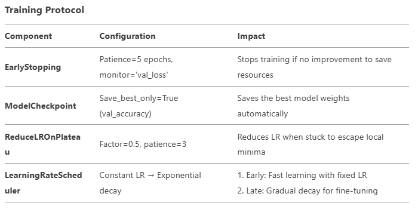

## **Recommendations For Implementation Of CNN Model**

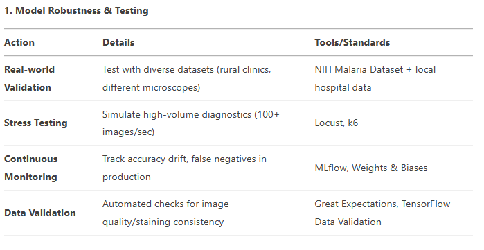

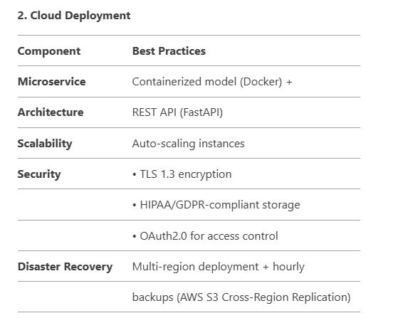

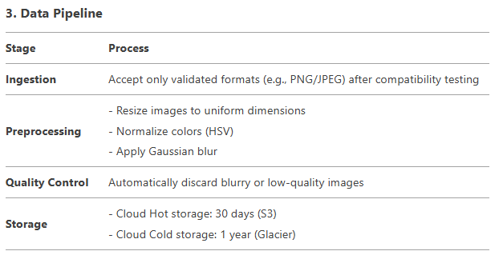

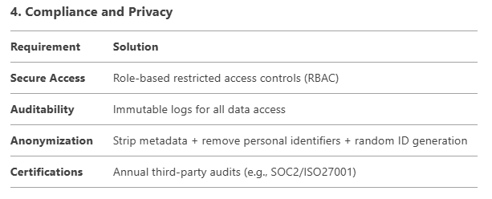

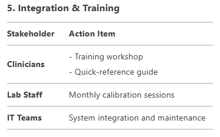

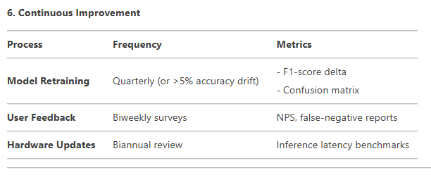

**7. System Integration Approach**

Achieving frictionless interoperability between the AI diagnostic system and current clinical infrastructure through is the crucial part of entire effort. If built system is difficult to adopt and doesn't integrate seamlessly in current workflow, all the effort is useless

**Workflow Integration:**

1. Embedding model outputs directly into existing lab devices is desirable but may prove difficult. Alternatively, model2 can be deployed on portable microscopes (where sufficient resources available), otherwise smartphones or current lab pcs. Later is cost effective and faster option.
2. System nust offer security and privacy of health data of all patients.
3. User Experience Alignment is important. Feedback nust be taken and system be aligned with it efficiently
4. Mirroring existing diagnostic report formats will make it easier for health professionals to adapt it.

**Technical Compatibility**

1. Cross-platform support (Windows/Linux/mobile)
2. Version-controlled APIs for backward compatibility

This ways Clinicians can adopt the tool without disrupting established diagnostic protocols.

## **Implementation Roadmap**

**Phase 1 (Pilot):**

- Deploy on smartphones/ tablets in few clinics
- Benchmark against manual microscopy (targeting : 95% concordance)

**Phase 2 (Scale):**

- Can be scaled to more smartphones targetting more number of clinics
- Also start deployment on fewer existing lab pcs. (targeting : 95% concordance)

**Phase 3 (Legacy and scaling):**

- Develop adapter dongles for traditional microscopes
- Scaling on smartphones and lab pcs

Develop adapter dongles for 10+ year old microscopes

### **Additional Considerations**

**Interoperability:** Ensure seamless integration with diverse electronic health systems and medical devices for smooth operation.

**User Feedback:** Establish channels for ongoing feedback to identify issues, improve usability, and boost user satisfaction.

**Cost Management**: Track and control costs related to deployment, maintenance, and updates, while offering transparent cost-benefit analyses to stakeholders.

### **Expected Benefits:**

1. **Improved Diagnostic Accuracy**: CNN models, when trained properly, can outperform human experts in recognizing malaria parasites in blood smears. The high accuracy and precision can reduce the risk of misdiagnosis.
2. **Faster Speed of diagnosis**: The AI system can process malaria detection at a much faster rate than manual methods, enabling quicker diagnosis. This is especially important in remote or resource-limited areas. The time to diagnose one sample could be reduced from an average of 15-30 minutes with manual microscopy to under 1 minute with an automated AI system.
3. **Scalability** in Resource-Limited Areas: CNN-based systems can be deployed in regions with limited access to medical professionals or diagnostic equipment, offering a scalable and cost-effective solution for malaria detection.
4. **Cost Savings in the Long Run:** While the initial setup might be costly, over time, automated systems can significantly reduce costs related to labor, training, and manual error correction.
5. **Better Allocation of Healthcare Resources:** Accurate and rapid diagnosis allows healthcare providers to more efficiently allocate resources, prioritize treatment, and deploy interventions to affected populations.

### **Expected Costs**

1. **Initial Development and Implementation Costs**: Developing and training a high-quality CNN model for malaria detection requires investment in data collection, model training, hardware, and software
2. **Ongoing Maintenance and Update**s: Regular maintenance, software updates, and model retraining are necessary to keep the AI system effective, especially in changing environments (e.g., new malaria strains).
3. **Data Annotation and Labeling** :High-quality, labeled datasets are crucial for training CNN models. This is cost that also requires time and effort from experts who annotate images or data.
4. **Integration and Adoption by Healthcare Providers**:Introducing AI systems into the workflow of healthcare facilities involves costs for training healthcare workers, adapting existing workflows, and ensuring that the new system integrates seamlessly with other health systems.
5. **Regulatory and Legal Costs:** Cost: In many regions, AI healthcare applications require regulatory approval (e.g., from the FDA, CE certification). These processes could involve compliance, testing, and legal consultation.
6. **Data Privacy and Security Concerns:** Ensuring that patient data is kept secure and complies with data privacy laws can add additional costs to AI system deployment.

### **Benefit-Cost Ratio (Rational Assumptions):**

**Potential Health System Savings:** Assuming the model reduces misdiagnosis by 20%, and with a cost reduction in labor and time spent on diagnoses, a healthcare facility might save good amount annually by deploying the AI system.

**Long-term Benefit:** Over 5 years, the benefits in terms of improved health outcomes, reduced hospitalizations, and faster detection could offset initial setup costs.

**Net Benefit Estimation:** If say the total cost of deployment (including development, hardware, and training) is 200,000 and the health system savings (diagnostic efficiency, prevention of misdiagnosis, etc.) reach $50,000 per year, the system could pay for itself within 4-5 years.

### **Potential Risks and Challenges**

1. **Data Quality and Availability** The effectiveness of the model depends on having high-quality, representative data. Collecting sufficient labeled data can be resource-intensive and challenging.
2. **Model Bias and Fairness** Biased data may lead to unfair or inaccurate predictions, particularly for underserved populations or diverse malaria strains. Ensuring data diversity is crucial and at the same time big challenge.
3. **Integration into Existing Healthcare Systems** Integrating AI into existing healthcare infrastructures may face challenges like limited resources or outdated equipment. Pilot programs can help identify and address issues.
4. **Regulatory and Legal Barriers** Obtaining regulatory approval for medical AI tools can be time-consuming and complex. Collaborating with regulatory bodies early can help expedite the process.
5. **High Costs of Implementation** Initial development and deployment costs can be high, especially for low-resource healthcare settings. Partnerships and cost-effective solutions can help reduce these costs.
6. **Limited Trust from the Public** Public skepticism about AI in healthcare can hinder adoption. Educational campaigns and transparent communication are key to building trust.
7. **Maintenance and Long-Term Viability** AI systems require ongoing updates and monitoring to remain effective. Planning for long-term maintenance and local capacity building is essential.

### **Further Analysis Needs**

1. Feasibility Study: Evaluate whether the technology can be realistically deployed in the target healthcare settings, considering factors like available infrastructure, technology readiness, and local needs.
2. Data Availability and Quality: Assess the availability and quality of data required for training the AI model at large scale. This includes ensuring there is sufficient labeled data for both parasitized and uninfected red blood cells. Perform an audit of existing datasets, ensuring diversity in geographic, demographic, and environmental factors to ensure the model generalizes well.
3. Regulatory Compliance: Understand the demand for AI-based malaria detection tools in healthcare settings and evaluate potential user adoption challenges. Consult with legal experts and regulatory bodies to understand the certification process and required documentation for compliance.
4. Market Demand and User Adoption: Understand the demand for AI-based malaria detection tools in healthcare settings and evaluate potential user adoption challenges. Conduct surveys, focus groups, or pilot studies with healthcare professionals to gauge interest, acceptance, and any barriers to adoption.
5. Cost-Benefit Analysis: further analyze the financials with professionals to understand associated costs with developing, deploying, and maintaining the system versus the expected benefits, both in terms of financial outcomes and health impact.
6. Risk Assessment: Identify potential risks associated with implementing the AI solution, such as technical failures, incorrect diagnoses, or loss of trust in AI-generated results.

## **Data Description**

There are a total of 24,958 train and 2,600 test images (colored) that we have taken from microscopic images. These images are of the following categories:

**Parasitized:** The parasitized cells contain the Plasmodium parasite which causes malaria  
**Uninfected:** The uninfected cells are free of the Plasmodium parasites

### **Mount the Drive**

```python
from google.colab import drive
drive.mount('/content/drive')
```

### **Loading libraries**

```python
#Loading libraries

import zipfile

import os

from PIL import Image

import numpy as np

import pandas as pd

import matplotlib.pyplot as plt

import seaborn as sns

from sklearn.model_selection import train_test_split

import tensorflow as tf

from tensorflow.keras.utils import to_categorical

# To ignore warnings
import warnings
warnings.filterwarnings('ignore')
# Suppress matplotlib warnings
warnings.filterwarnings("ignore", category=UserWarning, module="matplotlib.image")

# Remove the limit from the number of displayed columns and rows see the entire dataframe while printing it
pd.set_option("display.max_columns", None)

pd.set_option("display.max_rows", 200)
```

### **Let us load the data**

**Note:**

- You must download the dataset from the link provided on Olympus and upload the same to your Google Drive. Then unzip the folder.

```python
path = '/content/cell_images.zip'

# The data is provided as a zip file so we need to extract the files from the zip file
with zipfile.ZipFile(path, 'r') as zip_ref:

    zip_ref.extractall()
```

The extracted folder has different folders for train and test data will contain the different sizes of images for parasitized and uninfected cells within the respective folder name.

The size of all images must be the same and should be converted to 4D arrays so that they can be used as an input for the convolutional neural network. Also, we need to create the labels for both types of images to be able to train and test the model.

Let's do the same for the training data first and then we will use the same code for the test data as well.

```python
# Storing the path of the extracted "train" folder
train_dir = '/content/cell_images/train'

# Size of image so that each image has the same size
SIZE = 64

# Empty list to store the training images after they are converted to NumPy arrays
train_images = []

# Empty list to store the training labels (0 - uninfected, 1 - parasitized)
train_labels = []
```

```python
# Parasitized and uninfected folders within train folder
for folder_name in ['/parasitized/', '/uninfected/']:
    images_path = os.listdir(train_dir + folder_name) # Path of the folder

    for i, image_name in enumerate(images_path):

        try:
            image = Image.open(train_dir + folder_name + image_name) # Opening each image using the path of that image
            image = image.resize((SIZE, SIZE)) # Resizing each image to (64, 64)
            train_images.append(np.array(image))# Converting images to arrays and appending that array to the empty list defined above

            # Creating labels for parasitized and uninfected images
            if folder_name == '/parasitized/':
                train_labels.append(1)
            else:
                train_labels.append(0)
        except Exception:
            pass

# Converting lists to arrays
train_images = np.array(train_images)
train_labels = np.array(train_labels)
```

```python
# Storing the path of the extracted "test" folder
test_dir = '/content/cell_images/test'
SIZE = 64 # Size of image so that each image has the same size (it must be same as the train image size)

# Empty list to store the testing images after they are converted to NumPy arrays
test_images = []

# Empty list to store the testing labels (0 - uninfected, 1 - parasitized)
test_labels = []
```

```python
# parasitized and uninfected folders within the test folder
for folder_name in ['/parasitized/', '/uninfected/']:

    # Path of the folder
    images_path = os.listdir(test_dir + folder_name)

    for i, image_name in enumerate(images_path):

        try:
            # Opening each image using the path of that image
            image = Image.open(test_dir + folder_name + image_name)

            # Resizing each image to (64, 64)
            image = image.resize((SIZE, SIZE))

            # Converting images to arrays and appending that array to the empty list defined above
            test_images.append(np.array(image))

            # Creating labels for parasitized and uninfected images
            if folder_name == '/parasitized/':

                test_labels.append(1)

            else:

                test_labels.append(0)

        except Exception:

            pass

# Converting lists to arrays
test_images = np.array(test_images)

test_labels = np.array(test_labels)
```

### **Check the shape of train and test images**

```python
print("Shape of train images:", train_images.shape)
print("Shape of 1st train image:", train_images[0].shape)
print("Shape of test images:", test_images.shape) # Shape of test dataset
print("Shape of 1st test image:", test_images[0].shape) #Shape of first image in test dataset
```

```
Shape of train images: (24958, 64, 64, 3)
Shape of 1st train image: (64, 64, 3)
Shape of test images: (2600, 64, 64, 3)
Shape of 1st test image: (64, 64, 3)
```

### **Check the shape of train and test labels**

```python
# Checking Shape of labels
print("Shape of train labels:", train_labels.shape)
print("Shape of test labels:", test_labels.shape)
```

```
Shape of train labels: (24958,)
Shape of test labels: (2600,)
```

# **Observations and insights: _____**

1. The training dataset contains 24,958 images, each with dimensions 64x64 pixels and 3 color channels (RGB).The first training image's shape confirms this structure.
2. The testing dataset consists of 2,600 images, identically sized (64x64x3). The shape of the first image in the test set confirms this as well.
3. The training labels have a shape corresponding to the number of training images (24,958), and similarly, the test labels have a shape corresponding to the number of test images (2,600).
4. The original image sizes were not uniform and varied. We resized. Resizing was necessary to standardize the input to the CNN model. CNNs require consistent input dimensions for all images in a batch, and this resizing ensures that all images have the same shape (64x64 pixels in this case) regardless of their original dimensions. This standardization allows for efficient processing of the data by the neural network and avoids issues related to inconsistent input shapes.

### **Check the minimum and maximum range of pixel values for train and test images**

```python
print("Minimum pixel value of train images: ", np.amin(train_images))
print("Maximum pixel value of train images: ", np.amax(train_images))
print("Minimum pixel value of test images: ", np.amin(test_images))
print("Maximum pixel value of test images: ", np.amax(test_images))
```

```
Minimum pixel value of train images:  0
Maximum pixel value of train images:  255
Minimum pixel value of test images:  0
Maximum pixel value of test images:  255
```

```python
#Because numpy array represents a color image with multiple channels, we can specify the axis along which to calculate the minimum and maximum values.
print("Minimum pixel value of train images: ", np.amin(train_images, axis=(0, 1)))
print("Maximum pixel value of train images: ", np.amax(train_images, axis=(0, 1)))

print("Minimum pixel value of test images: ", np.amin(test_images, axis=(0, 1)))
print("Maximum pixel value of test images: ", np.amax(test_images, axis=(0, 1)))
```

```
Minimum pixel value of train images:  [[0 0 0]
 [0 0 0]
 [0 0 0]
 [0 0 0]
 [0 0 0]
 [0 0 0]
 [0 0 0]
 [0 0 0]
 [0 0 0]
 [0 0 0]
 [0 0 0]
 [0 0 0]
 [0 0 0]
 [0 0 0]
 [0 0 0]
```

[output cut: 241 more lines]

#### **Observations and insights: _____**

1. The minimum pixel value across all images in both training and testing sets is 0. The maximum pixel value across all images in both training and testing sets is 255.
2. This indicates that each pixel is having an intensity value ranging from 0 (black) to 255 (white).
3. When we look at minimum pixel value of train and test images across all the three channels, the values are same [0,0,0] and for maximum pixel values for train and test images are [255,255,255]. This is also consistent with our previous finding, that the pixel values are between 0-255.
4. We need to normalize the images. It is important for improving model training and performance because it scales the pixel intensity values to a smaller, more manageable range. This prevents features with larger values from dominating the learning process and helps in faster convergence of the model.

### **Count the number of values in both uninfected and parasitized**

```python
#Count the number of values in both uninfected and parasitized in train set

unique, counts = np.unique(train_labels, return_counts=True)
for value, count in zip(unique, counts):
    if value == 0:
        print("Uninfected:", count)
    else:
        print("Parasitized:", count)
```

```
Uninfected: 12376
Parasitized: 12582
```

```python
#Count the number of values in both uninfected and parasitized in test set

unique, counts = np.unique(test_labels, return_counts=True)
for value, count in zip(unique, counts):
    if value == 0:
        print("Uninfected:", count)
    else:
        print("Parasitized:", count)
```

```
Uninfected: 1300
Parasitized: 1300
```

```python
# Normalize the train and test images by dividing it by 255 and convert them to float32 using astype function
train_images = (train_images/255).astype('float32')

test_images = (test_images/255).astype('float32')
```

```python
print("Minimum pixel value of train images: ", np.amin(train_images, axis=(0, 1)))
print("Maximum pixel value of train images: ", np.amax(train_images, axis=(0, 1)))

print("Minimum pixel value of test images: ", np.amin(test_images, axis=(0, 1)))
print("Maximum pixel value of test images: ", np.amax(test_images, axis=(0, 1)))
```

[output not shown]

[output cut: 201 more lines]

```
 [1.         0.8784314  0.81960785]
 [1.         0.8901961  0.84313726]
 [1.         0.88235295 0.84705883]
 [1.         0.8862745  0.81960785]
 [1.         0.9137255  0.8235294 ]
 [1.         0.9137255  0.85490197]
 [1.         0.88235295 0.83137256]
 [1.         0.9019608  0.8235294 ]
 [1.         0.8901961  0.81960785]
 [1.         0.8980392  0.8117647 ]
 [1.         0.8901961  0.8039216 ]
 [1.         0.8784314  0.8235294 ]
 [1.         0.90588236 0.83137256]
 [1.         0.8666667  0.8156863 ]
 [1.         0.89411765 0.81960785]]
```

#### **Observations and insights: _____**

After normalization, the pixel values now range from 0 to 1. This prevents features with larger values from dominating the learning process and helps in faster convergence of the model.

### **Plot to check if the data is balanced**

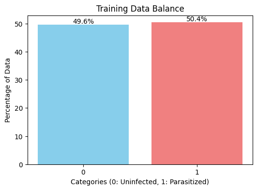

```python
#check if training data is balanced
unique, counts = np.unique(train_labels, return_counts=True)

# Calculate percentages
percentages = (counts / len(train_labels)) * 100

# Create the bar plot
plt.figure(figsize=(6, 4))
bars = plt.bar(unique, percentages, color=['skyblue', 'lightcoral'])

# Add percentage labels on top of the bars
for bar, percentage in zip(bars, percentages):
    yval = bar.get_height()
    plt.text(bar.get_x() + bar.get_width()/2, yval, f'{percentage:.1f}%', ha='center', va='bottom')

plt.xlabel("Categories (0: Uninfected, 1: Parasitized)")
plt.ylabel("Percentage of Data")
plt.title("Training Data Balance")
plt.xticks(unique)
plt.show()
```

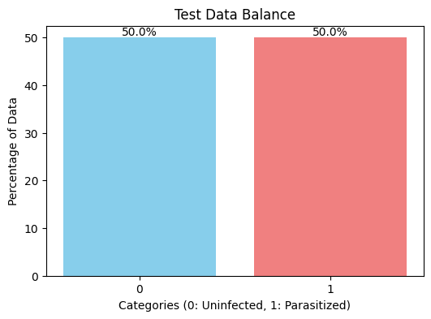

```python
#check if tets data is balanced by creating a bar plot

unique, counts = np.unique(test_labels, return_counts=True)

# Calculate percentages
percentages = (counts / len(test_labels)) * 100

# Create the bar plot
plt.figure(figsize=(6, 4))
bars = plt.bar(unique, percentages, color=['skyblue', 'lightcoral'])

# Add percentage labels on top of the bars
for bar, percentage in zip(bars, percentages):
    yval = bar.get_height()
    plt.text(bar.get_x() + bar.get_width()/2, yval, f'{percentage:.1f}%', ha='center', va='bottom')

plt.xlabel("Categories (0: Uninfected, 1: Parasitized)")
plt.ylabel("Percentage of Data")
plt.title("Test Data Balance")
plt.xticks(unique)
plt.show()
```

### **Visualize the images with subplot(6, 6) and figsize = (12, 12)**

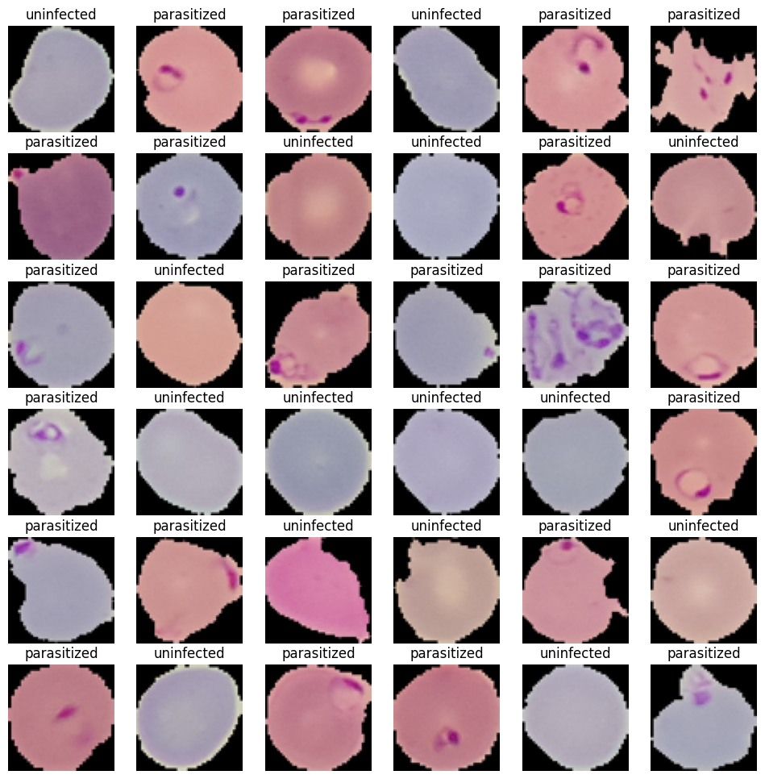

```python
plt.figure(1, figsize = (12 , 12))

for n in range(1, 37):

    plt.subplot(6, 6, n)
    index = int(np.random.randint(0, train_images.shape[0], 1))

    if train_labels[index] == 1:
        plt.title('parasitized')
    else:
        plt.title('uninfected')

    plt.imshow(train_images[index])
    plt.axis('off')
```

#### **Observations and insights:**

The parasitized cells contain reddish purple dots inside while uninfected ones are clear. These dots are the parasites that cause malaria

### **Plotting the mean images for parasitized and uninfected**

```python
# Function to find the mean
def find_mean_img(full_mat, title):

    # Calculate the average
    mean_img = np.mean(full_mat, axis = 0)[0]

    # Reshape it back to a matrix
    plt.imshow(mean_img)
    plt.title(f'Average {title}')
    plt.axis('off')
    plt.show()

    return mean_img
```

**Mean image for parasitized**

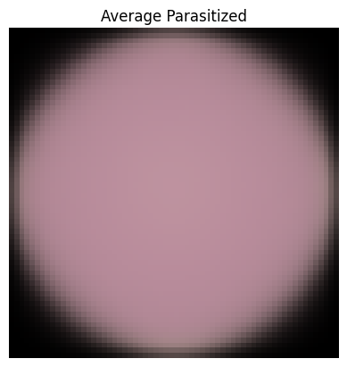

```python
# Finding mean of parasitized. If the label = 1 then the image is parasitised and if the label = 0 then the image is uninfected
parasitized_data = []  # Create a list to store the parasitized data

for img, label in zip(train_images, train_labels):

        if label == 1:

              parasitized_data.append([img])

parasitized_mean = find_mean_img(np.array(parasitized_data), 'Parasitized')   # find the mean
```

**Mean image for uninfected**

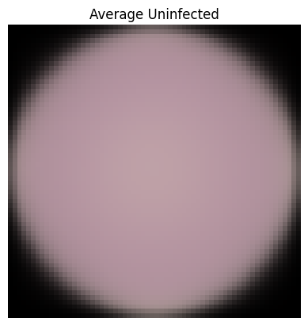

```python
# Finding mean of uninfected. If the label = 1 then the image is parasitised and if the label = 0 then the image is uninfected
uninfected_data = []  # Create a list to store the parasitized data

for img, label in zip(train_images, train_labels):

        if label == 0:

              uninfected_data.append([img])

uninfected_mean = find_mean_img(np.array(uninfected_data), 'Uninfected')   # find the mean
```

#### **Observations and insights: _____**

The color intensity of the parasitized and uninfected cells vary. The mean image for parasitized images is slightly darker than the mean image for uninfected images.

### **Converting RGB to HSV of Images using OpenCV**

### **Converting the train data**

I converted using cv2 (code for which is commented) but found that tf.image.rgb_to_hsv gives better results durinng model trainng. Hence I am going ahead with tf.image.rgb_to_hsv

```python
## Converting training RGB to HSV of Images using cv2
import cv2
gfx=[]   # to hold the HSV image array
for i in range(train_images.shape[0]):
  # a=cv2.cvtColor(train_images[i],cv2.COLOR_BGR2HSV)
  a= tf.image.rgb_to_hsv(train_images[i])
  gfx.append(a)
gfx=np.array(gfx)
```

### **Converting the test data**

```python
#converting test data and saving it

import cv2
gfx2=[]   # to hold the HSV image array
for i in range(test_images.shape[0]):
  # a=cv2.cvtColor(test_images[i],cv2.COLOR_BGR2HSV)
  a= tf.image.rgb_to_hsv(test_images[i])
  gfx2.append(a)
gfx2=np.array(gfx2)
```

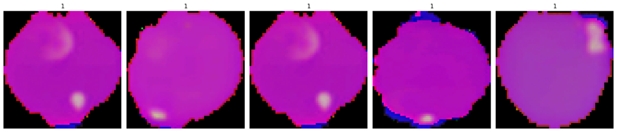

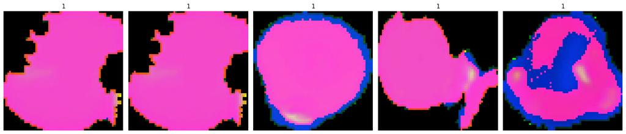

```python
#Viewing train data
viewimage=np.random.randint(1,100,5)
fig,ax=plt.subplots(1,5,figsize=(18,18))
for t,i in zip(range(5),viewimage):
  Title=train_labels[i]
  ax[t].set_title(Title)
  ax[t].imshow(gfx[i])
  ax[t].set_axis_off()
  fig.tight_layout()

#visualize the images in the test data
viewimage=np.random.randint(1,100,5)
fig,ax=plt.subplots(1,5,figsize=(18,18))
for t,i in zip(range(5),viewimage):
  Title=test_labels[i]
  ax[t].set_title(Title)
  ax[t].imshow(gfx2[i])
  ax[t].set_axis_off()
  fig.tight_layout()
```

#### **Observations and insights: _____**

1. Coversion gives a good contrast. The blood cells are now segmented clearly from background.
2. The hot pink colored spots are blood cells and yellow dots inside are parasites.
3. Parasites can be more easily isolated
4. Using HSV images makes processing algorithms less sensitive to changes in lighting conditions. This can be helpful in scenarios where images are captured under different lighting or where shadows might be present.

### **Processing Images using Gaussian Blurring**

### **Gaussian Blurring on train data**

```python
def apply_gaussian_blur_batch(images, batch_size):
    """
    Apply Gaussian blur to a batch of images

    Parameters:
        images
        batch_size

    Returns:
        batch of blurred images.
    """
    kernel_size=(5, 5)
    sigma=0.0

    num_samples = len(images)
    num_batches = num_samples // batch_size
    remaining_samples = num_samples % batch_size

    blurred_images = []

    # Process full batches
    for i in range(num_batches):
        batch = images[i * batch_size: (i + 1) * batch_size]
        batch_blurred = [cv2.GaussianBlur(img, kernel_size, sigma) for img in batch]
        blurred_images.extend(batch_blurred)

    # Process remaining images
    if remaining_samples > 0:
        remaining_batch = images[num_batches * batch_size:]
        remaining_blurred_batch = [cv2.GaussianBlur(img, kernel_size, sigma) for img in remaining_batch]
        blurred_images.extend(remaining_blurred_batch)

    return np.array(blurred_images)
```

```python
#guassian blurring on train data
gbx = []
gbx = apply_gaussian_blur_batch(gfx,batch_size = 4)
```

### **Gaussian Blurring on test data**

```python
#guassian blurring on test data
gbx2 = []
gbx2 = apply_gaussian_blur_batch(gfx2,batch_size = 4)
```

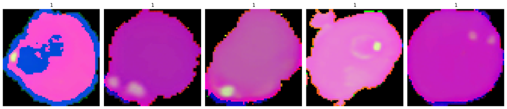

```python
#image before blurring
viewimage=np.random.randint(1,100,5)
fig,ax=plt.subplots(1,5,figsize=(18,18))
for t,i in zip(range(5),viewimage):
  Title=test_labels[i]
  ax[t].set_title(Title)
  ax[t].imshow(gfx[i])
  ax[t].set_axis_off()
  fig.tight_layout()
```

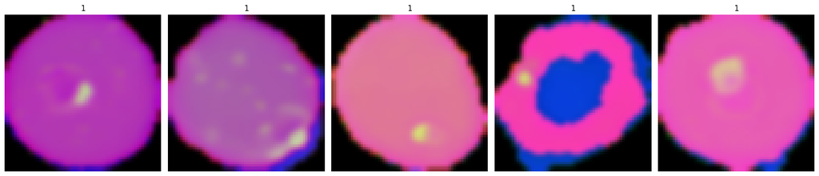

```python
#image after guassian blurring
viewimage=np.random.randint(1,100,5)
fig,ax=plt.subplots(1,5,figsize=(18,18))
for t,i in zip(range(5),viewimage):
  Title=test_labels[i]
  ax[t].set_title(Title)
  ax[t].imshow(gbx[i])
  ax[t].set_axis_off()
  fig.tight_layout()
```

#### **Observations and insights: _____**

1. After applying Gaussian blur, the images appear smoother, with reduced noise and finer details softened.  
   This preprocessing step can help the CNN model focus on the more prominent features, making it less sensitive to minor variations or noise in the input images. Also important thing is every infected cell distinctly displays the infected yeloow spots. This suggests that the essential features for classification are visible after the blurring operation with lesser noise.

**HSV + Gaussian Blurring**

**Pros:**

HSV color space separates color from intensity, which can be helpful for highlighting parasite regions based on color contrast.

Gaussian Blurring smooths the image and removes noise — potentially reducing overfitting and improving feature focus.

**Cons:**

Might blur out tiny or sharp parasite features, especially if blur is too aggressive.Color transformations may distort actual biological features if not tuned well.For this it is important to work with domain experts but here with these samples HSV and blurring doesn't seem to fade away relevant features

**Issue With RGB IMAGES :

1. **Oscillation Validation Accuracy** (when model trained with RGB Images) When trained model on rgb images there was always Oscillating validation accuracy. It is often a sign of noisy input. Model is learning, but not generalizing well to unseen data.

Overfitting or underfitting might be happening. Without preprocessing like blurring or color normalization (HSV), the model seems to pick up irrelevant patterns Though the raw image model performed great overall, but its instability on validation hints that the raw input might benefit from some pre-cleaning.

2. While accuracy of RGB was **~97%, higher 98%** could be achieved using model2 trained on HSV+ blurred images with lesser false alarms (FP) . Infact recall of parasitized class with preprocessed images is 99%.

**Higher False alarms**- When trained the model on RGB images, though accuracy was good but there were higher false detections and this can lead to breaking customer trust and higher costs

3. **Real-World Scenario: Deployment on Mobiles & Microscopes**

In practice, as we plan deployments on portable devices like smartphones and microscopes, their lenses can inevitably include: Shadows from uneven lighting, Glare, reflections, color tints, Sensor noise, dust, focus variation.**These artifacts may confuse a model trained only on clean lab images.**

Hence , data pre processing techniques like HSV+blurring can always be advantageous and after testing model on both , giving model on HSV+Guassian blurring

**Other things to try**

1. Bilateral Filtering - This is highly effective at noise removal while focus more on preserving edges. But let's keep it simple for now and stick with Gaussian Blurring.
2. Adaptive histogram equalization (like CLAHE) to reduce noise but preserve structure.

Also before building the model lets check how hsv conversion and blurring impact normalization of the images

```python
print("Minimum pixel value of train images: ", np.amin(gbx))
print("Maximum pixel value of train images: ", np.amax(gbx))
print("Minimum pixel value of test images: ", np.amin(gbx2))
print("Maximum pixel value of test images: ", np.amax(gbx2))
```

```
Minimum pixel value of train images:  0.0
Maximum pixel value of train images:  0.9977529
Minimum pixel value of test images:  0.0
Maximum pixel value of test images:  0.99774975
```

Still we see that the pixel range is between 0-1 and hence conversion to HSV and blurring didn't impact the data normalization and these images can be used for model training

## **Model Building**

### **Base Model**

**Note:** The Base Model has been fully built and evaluated with all outputs shown to give an idea about the process of the creation and evaluation of the performance of a CNN architecture. A similar process can be followed in iterating to build better-performing CNN architectures.

### **Importing the required libraries for building and training our Model**

```python
from tensorflow.keras import backend

from tensorflow.keras.utils import to_categorical

from tensorflow.keras.models import Sequential

from tensorflow.keras.layers import Conv2D, MaxPooling2D, Dense, Flatten, Dropout,  BatchNormalization, LeakyReLU

from tensorflow.keras.optimizers import Adam

from tensorflow.keras.callbacks import EarlyStopping, ModelCheckpoint

from random import shuffle
from sklearn.metrics import classification_report
from sklearn.metrics import confusion_matrix
import seaborn as sns
```

```python
#Common function that clears the Keras backend and resets the random seed
def clear_backend_gen_random_seed():
  #clear the previous model's history from the Keras backend
  backend.clear_session()

  # Fixing the seed for random number generators so that we can ensure we receive the same output everytime
  np.random.seed(42)
  import random
  random.seed(42)
  tf.random.set_seed(42)
```

```python
#Common confusion_matrix plotting function that can be used for every model

def plot_confusion_matrix(trained_model, X_test, y_test, categories):
    """
    Plots the confusion matrix and prints the classification report.

    Args:
        trained_model: The trained Keras model.
        X_test: The test data.
        y_test: The true labels for the test data (one-hot encoded).
        categories: A list of category names for the labels.
    """

    pred = trained_model.predict(X_test)
    pred = np.argmax(pred, axis=1)
    y_true = np.argmax(y_test, axis=1)

    cm = confusion_matrix(y_true, pred)
    print(classification_report(y_true, pred))

    plt.figure(figsize=(8, 5))
    sns.heatmap(cm, annot=True, fmt='.0f', xticklabels=categories, yticklabels=categories)
    plt.ylabel('Actual')
    plt.xlabel('Predicted')
    plt.yticks(rotation=0)  # Ensure y-axis labels are readable
    plt.show()
```

```python
# Common Function to plot train and validation accuracy that can be used for every model

def plot_accuracy(history):

    N = len(history.history["accuracy"])

    plt.figure(figsize = (7, 7))
    plt.plot(np.arange(0, N), history.history["accuracy"], label = "train_accuracy", ls = '--')
    plt.plot(np.arange(0, N), history.history["val_accuracy"], label = "val_accuracy", ls = '--')

    plt.title("Accuracy vs Epoch")
    plt.xlabel("Epochs")
    plt.ylabel("Accuracy")
    plt.legend(loc="upper left")
```

#### **One Hot Encoding the train and test labels**

```python
CATEGORIES = ["parasitized", "uninfected"]
```

```python
# Encode train labels
train_labels = to_categorical(train_labels, 2)

# Encode test labels
test_labels = to_categorical(test_labels, 2)
```

### **Building the model**

```python
clear_backend_gen_random_seed()
```

```python
#creating sequential model
model=Sequential()

#Convolutional Layer with 32 filters, maxpooling and dropouts
model.add(Conv2D(filters=32,kernel_size=2,padding="same",activation="relu",input_shape=(64,64,3)))
model.add(MaxPooling2D(pool_size=2))
model.add(Dropout(0.2))
model.add(Conv2D(filters=32,kernel_size=2,padding="same",activation="relu"))
model.add(MaxPooling2D(pool_size=2))
model.add(Dropout(0.2))
model.add(Conv2D(filters=32,kernel_size=2,padding="same",activation="relu"))
model.add(MaxPooling2D(pool_size=2))
model.add(Dropout(0.2))

# Flatten the output
model.add(Flatten())

# Fully Connected Layer
model.add(Dense(512,activation="relu"))
model.add(Dropout(0.4))

model.add(Dense(2,activation="softmax"))#2 represent output layer neurons
model.summary()
```

```
Model: "sequential"
```

```
┏━━━━━━━━━━━━━━━━━━━━━━━━━━━━━━━━━━━━━━┳━━━━━━━━━━━━━━━━━━━━━━━━━━━━━┳━━━━━━━━━━━━━━━━━┓
┃ Layer (type)                         ┃ Output Shape                ┃         Param # ┃
┡━━━━━━━━━━━━━━━━━━━━━━━━━━━━━━━━━━━━━━╇━━━━━━━━━━━━━━━━━━━━━━━━━━━━━╇━━━━━━━━━━━━━━━━━┩
│ conv2d (Conv2D)                      │ (None, 64, 64, 32)          │             416 │
├──────────────────────────────────────┼─────────────────────────────┼─────────────────┤
│ max_pooling2d (MaxPooling2D)         │ (None, 32, 32, 32)          │               0 │
├──────────────────────────────────────┼─────────────────────────────┼─────────────────┤
│ dropout (Dropout)                    │ (None, 32, 32, 32)          │               0 │
├──────────────────────────────────────┼─────────────────────────────┼─────────────────┤
│ conv2d_1 (Conv2D)                    │ (None, 32, 32, 32)          │           4,128 │
├──────────────────────────────────────┼─────────────────────────────┼─────────────────┤
│ max_pooling2d_1 (MaxPooling2D)       │ (None, 16, 16, 32)          │               0 │
├──────────────────────────────────────┼─────────────────────────────┼─────────────────┤
│ dropout_1 (Dropout)                  │ (None, 16, 16, 32)          │               0 │
├──────────────────────────────────────┼─────────────────────────────┼─────────────────┤
│ conv2d_2 (Conv2D)                    │ (None, 16, 16, 32)          │           4,128 │
├──────────────────────────────────────┼─────────────────────────────┼─────────────────┤
│ max_pooling2d_2 (MaxPooling2D)       │ (None, 8, 8, 32)            │               0 │
├──────────────────────────────────────┼─────────────────────────────┼─────────────────┤
│ dropout_2 (Dropout)                  │ (None, 8, 8, 32)            │               0 │
├──────────────────────────────────────┼─────────────────────────────┼─────────────────┤
│ flatten (Flatten)                    │ (None, 2048)                │               0 │
├──────────────────────────────────────┼─────────────────────────────┼─────────────────┤
│ dense (Dense)                        │ (None, 512)                 │       1,049,088 │
├──────────────────────────────────────┼─────────────────────────────┼─────────────────┤
│ dropout_3 (Dropout)                  │ (None, 512)                 │               0 │
├──────────────────────────────────────┼─────────────────────────────┼─────────────────┤
│ dense_1 (Dense)                      │ (None, 2)                   │           1,026 │
└──────────────────────────────────────┴─────────────────────────────┴─────────────────┘
```

```
 Total params: 1,058,786 (4.04 MB)
```

```
 Trainable params: 1,058,786 (4.04 MB)
```

```
 Non-trainable params: 0 (0.00 B)
```

### **Compiling the model**

```python
# Compiling the model
model.compile(optimizer = Adam(), loss = 'categorical_crossentropy', metrics = ['accuracy'])
```

**Using Callbacks**

```python
# The following lines of code saves the best model's parameters if training accuracy goes down on further training
es = EarlyStopping(monitor = 'val_loss', mode = 'min', verbose = 1, patience = 3)
# Early stopping callback to stop the training if accuracy doesn't improve after a certain number of epohocks
mc = ModelCheckpoint('cnn_model_basic.keras', monitor = 'val_accuracy', mode = 'max', verbose = 1, save_best_only = True)
```

```python
#Training the model
history = model.fit(gbx, train_labels, batch_size = 32, callbacks =  [mc,es], validation_split = 0.2, epochs = 20, verbose = 1)
```

```
624/624 ━━━━━━━━━━━━━━━━━━━━ 0s 12ms/step - accuracy: 0.7517 - loss: 0.4841
Epoch 1: val_accuracy improved from -inf to 0.97296, saving model to cnn_model_basic.keras
624/624 ━━━━━━━━━━━━━━━━━━━━ 15s 16ms/step - accuracy: 0.7519 - loss: 0.4838 - val_accuracy: 0.9730 - val_loss: 0.2439
618/624 ━━━━━━━━━━━━━━━━━━━━ 0s 6ms/step - accuracy: 0.9582 - loss: 0.1269
Epoch 2: val_accuracy improved from 0.97296 to 0.99319, saving model to cnn_model_basic.keras
624/624 ━━━━━━━━━━━━━━━━━━━━ 11s 7ms/step - accuracy: 0.9583 - loss: 0.1268 - val_accuracy: 0.9932 - val_loss: 0.0794
620/624 ━━━━━━━━━━━━━━━━━━━━ 0s 5ms/step - accuracy: 0.9665 - loss: 0.0995
Epoch 3: val_accuracy did not improve from 0.99319
624/624 ━━━━━━━━━━━━━━━━━━━━ 3s 6ms/step - accuracy: 0.9665 - loss: 0.0995 - val_accuracy: 0.9888 - val_loss: 0.0906
620/624 ━━━━━━━━━━━━━━━━━━━━ 0s 5ms/step - accuracy: 0.9708 - loss: 0.0862
Epoch 4: val_accuracy did not improve from 0.99319
624/624 ━━━━━━━━━━━━━━━━━━━━ 3s 6ms/step - accuracy: 0.9708 - loss: 0.0862 - val_accuracy: 0.9890 - val_loss: 0.0807
616/624 ━━━━━━━━━━━━━━━━━━━━ 0s 5ms/step - accuracy: 0.9725 - loss: 0.0801
Epoch 5: val_accuracy did not improve from 0.99319
624/624 ━━━━━━━━━━━━━━━━━━━━ 4s 6ms/step - accuracy: 0.9725 - loss: 0.0802 - val_accuracy: 0.9870 - val_loss: 0.0791
624/624 ━━━━━━━━━━━━━━━━━━━━ 0s 5ms/step - accuracy: 0.9730 - loss: 0.0811
Epoch 6: val_accuracy did not improve from 0.99319
624/624 ━━━━━━━━━━━━━━━━━━━━ 5s 6ms/step - accuracy: 0.9730 - loss: 0.0811 - val_accuracy: 0.9864 - val_loss: 0.0696
623/624 ━━━━━━━━━━━━━━━━━━━━ 0s 5ms/step - accuracy: 0.9762 - loss: 0.0732
Epoch 7: val_accuracy did not improve from 0.99319
624/624 ━━━━━━━━━━━━━━━━━━━━ 3s 5ms/step - accuracy: 0.9762 - loss: 0.0732 - val_accuracy: 0.9888 - val_loss: 0.0559
621/624 ━━━━━━━━━━━━━━━━━━━━ 0s 5ms/step - accuracy: 0.9752 - loss: 0.0702
Epoch 8: val_accuracy did not improve from 0.99319
624/624 ━━━━━━━━━━━━━━━━━━━━ 4s 6ms/step - accuracy: 0.9752 - loss: 0.0702 - val_accuracy: 0.9856 - val_loss: 0.0776
624/624 ━━━━━━━━━━━━━━━━━━━━ 0s 6ms/step - accuracy: 0.9781 - loss: 0.0648
Epoch 9: val_accuracy did not improve from 0.99319
624/624 ━━━━━━━━━━━━━━━━━━━━ 4s 6ms/step - accuracy: 0.9781 - loss: 0.0648 - val_accuracy: 0.9860 - val_loss: 0.0671
624/624 ━━━━━━━━━━━━━━━━━━━━ 0s 5ms/step - accuracy: 0.9788 - loss: 0.0618
Epoch 10: val_accuracy did not improve from 0.99319
624/624 ━━━━━━━━━━━━━━━━━━━━ 4s 6ms/step - accuracy: 0.9788 - loss: 0.0618 - val_accuracy: 0.9830 - val_loss: 0.0752
Epoch 10: early stopping
```

### **Evaluating the model on test data**

```python
accuracy = model.evaluate(gbx2, test_labels, verbose = 1)
print('\n', 'Test_Accuracy:', accuracy[1])
```

```
82/82 ━━━━━━━━━━━━━━━━━━━━ 1s 9ms/step - accuracy: 0.9718 - loss: 0.0781

 Test_Accuracy: 0.9757692217826843
```

**Plotting the confusion matrix**

```
82/82 ━━━━━━━━━━━━━━━━━━━━ 1s 6ms/step
              precision    recall  f1-score   support

           0       0.53      0.94      0.68      1300
           1       0.75      0.17      0.28      1300

    accuracy                           0.56      2600
   macro avg       0.64      0.56      0.48      2600
weighted avg       0.64      0.56      0.48      2600
```

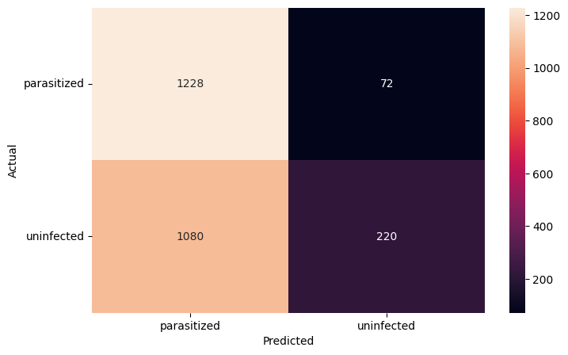

```python
plot_confusion_matrix(model, test_images, test_labels, CATEGORIES)
```

**Plotting the train and validation curves**

[figure not shown]

```python
plot_accuracy(history)
```

Observations on the Model:

So now let's try to build another model with few more add on layers and try to check if we can try to improve the model. Therefore try to build a model by adding few layers if required and altering the activation functions.

### **Model 1**

#### **Trying to improve the performance of our model by adding new layers**

```python
clear_backend_gen_random_seed()
```

### **Building the Model**

```python
#creating sequential model by adding more layers
model1=Sequential()

# Build the model here
model1.add(Conv2D(filters=32,kernel_size=2,padding="same",activation="relu",input_shape=(64,64,3)))
model1.add(MaxPooling2D(pool_size=2))
model1.add(Dropout(0.2))
model1.add(Conv2D(filters=32,kernel_size=2,padding="same",activation="relu"))
model1.add(MaxPooling2D(pool_size=2))
model1.add(Dropout(0.2))
model1.add(Conv2D(filters=32,kernel_size=2,padding="same",activation="relu"))
model1.add(MaxPooling2D(pool_size=2))
model1.add(Dropout(0.2))
model1.add(Conv2D(filters=32,kernel_size=2,padding="same",activation="relu"))
model1.add(MaxPooling2D(pool_size=2))
model1.add(Dropout(0.2))


model1.add(Flatten())

model1.add(Dense(512,activation="relu"))
model1.add(Dropout(0.4))
model1.add(Dense(2,activation="softmax"))#2 represent output layer neurons


model1.summary()
```

```
Model: "sequential"
```

```
┏━━━━━━━━━━━━━━━━━━━━━━━━━━━━━━━━━━━━━━┳━━━━━━━━━━━━━━━━━━━━━━━━━━━━━┳━━━━━━━━━━━━━━━━━┓
┃ Layer (type)                         ┃ Output Shape                ┃         Param # ┃
┡━━━━━━━━━━━━━━━━━━━━━━━━━━━━━━━━━━━━━━╇━━━━━━━━━━━━━━━━━━━━━━━━━━━━━╇━━━━━━━━━━━━━━━━━┩
│ conv2d (Conv2D)                      │ (None, 64, 64, 32)          │             416 │
├──────────────────────────────────────┼─────────────────────────────┼─────────────────┤
│ max_pooling2d (MaxPooling2D)         │ (None, 32, 32, 32)          │               0 │
├──────────────────────────────────────┼─────────────────────────────┼─────────────────┤
│ dropout (Dropout)                    │ (None, 32, 32, 32)          │               0 │
├──────────────────────────────────────┼─────────────────────────────┼─────────────────┤
│ conv2d_1 (Conv2D)                    │ (None, 32, 32, 32)          │           4,128 │
├──────────────────────────────────────┼─────────────────────────────┼─────────────────┤
│ max_pooling2d_1 (MaxPooling2D)       │ (None, 16, 16, 32)          │               0 │
├──────────────────────────────────────┼─────────────────────────────┼─────────────────┤
│ dropout_1 (Dropout)                  │ (None, 16, 16, 32)          │               0 │
├──────────────────────────────────────┼─────────────────────────────┼─────────────────┤
│ conv2d_2 (Conv2D)                    │ (None, 16, 16, 32)          │           4,128 │
├──────────────────────────────────────┼─────────────────────────────┼─────────────────┤
│ max_pooling2d_2 (MaxPooling2D)       │ (None, 8, 8, 32)            │               0 │
├──────────────────────────────────────┼─────────────────────────────┼─────────────────┤
│ dropout_2 (Dropout)                  │ (None, 8, 8, 32)            │               0 │
├──────────────────────────────────────┼─────────────────────────────┼─────────────────┤
│ conv2d_3 (Conv2D)                    │ (None, 8, 8, 32)            │           4,128 │
├──────────────────────────────────────┼─────────────────────────────┼─────────────────┤
│ max_pooling2d_3 (MaxPooling2D)       │ (None, 4, 4, 32)            │               0 │
├──────────────────────────────────────┼─────────────────────────────┼─────────────────┤
│ dropout_3 (Dropout)                  │ (None, 4, 4, 32)            │               0 │
├──────────────────────────────────────┼─────────────────────────────┼─────────────────┤
│ flatten (Flatten)                    │ (None, 512)                 │               0 │
├──────────────────────────────────────┼─────────────────────────────┼─────────────────┤
│ dense (Dense)                        │ (None, 512)                 │         262,656 │
├──────────────────────────────────────┼─────────────────────────────┼─────────────────┤
│ dropout_4 (Dropout)                  │ (None, 512)                 │               0 │
├──────────────────────────────────────┼─────────────────────────────┼─────────────────┤
│ dense_1 (Dense)                      │ (None, 2)                   │           1,026 │
└──────────────────────────────────────┴─────────────────────────────┴─────────────────┘
```

```
 Total params: 276,482 (1.05 MB)
```

```
 Trainable params: 276,482 (1.05 MB)
```

```
 Non-trainable params: 0 (0.00 B)
```

### **Compiling the model**

```python
model1.compile(optimizer = Adam(), loss = 'categorical_crossentropy', metrics = ['accuracy'])
```

**Using Callbacks**

```python
# The following lines of code saves the best model's parameters if training accuracy goes down on further training
es = EarlyStopping(monitor = 'val_loss', mode = 'min', verbose = 1, patience = 3)
mc = ModelCheckpoint('mdl1.keras', monitor = 'val_accuracy', mode = 'max', verbose = 1, save_best_only = True)
```

**Fit and Train the model**

```python
history1 = model1.fit(gbx, train_labels, batch_size = 32, callbacks = [es,mc],  validation_split = 0.2, epochs = 20, verbose = 1)
```

```
624/624 ━━━━━━━━━━━━━━━━━━━━ 0s 11ms/step - accuracy: 0.7726 - loss: 0.4484
Epoch 1: val_accuracy improved from -inf to 0.98558, saving model to mdl1.keras
624/624 ━━━━━━━━━━━━━━━━━━━━ 19s 14ms/step - accuracy: 0.7728 - loss: 0.4481 - val_accuracy: 0.9856 - val_loss: 0.1409
618/624 ━━━━━━━━━━━━━━━━━━━━ 0s 5ms/step - accuracy: 0.9634 - loss: 0.1098
Epoch 2: val_accuracy improved from 0.98558 to 0.98878, saving model to mdl1.keras
624/624 ━━━━━━━━━━━━━━━━━━━━ 7s 6ms/step - accuracy: 0.9634 - loss: 0.1098 - val_accuracy: 0.9888 - val_loss: 0.0931
618/624 ━━━━━━━━━━━━━━━━━━━━ 0s 5ms/step - accuracy: 0.9696 - loss: 0.0952
Epoch 3: val_accuracy improved from 0.98878 to 0.98918, saving model to mdl1.keras
624/624 ━━━━━━━━━━━━━━━━━━━━ 3s 5ms/step - accuracy: 0.9696 - loss: 0.0952 - val_accuracy: 0.9892 - val_loss: 0.0588
624/624 ━━━━━━━━━━━━━━━━━━━━ 0s 5ms/step - accuracy: 0.9732 - loss: 0.0848
Epoch 4: val_accuracy did not improve from 0.98918
624/624 ━━━━━━━━━━━━━━━━━━━━ 6s 6ms/step - accuracy: 0.9732 - loss: 0.0848 - val_accuracy: 0.9872 - val_loss: 0.0715
617/624 ━━━━━━━━━━━━━━━━━━━━ 0s 4ms/step - accuracy: 0.9742 - loss: 0.0806
Epoch 5: val_accuracy did not improve from 0.98918
624/624 ━━━━━━━━━━━━━━━━━━━━ 3s 5ms/step - accuracy: 0.9742 - loss: 0.0806 - val_accuracy: 0.9860 - val_loss: 0.0649
618/624 ━━━━━━━━━━━━━━━━━━━━ 0s 4ms/step - accuracy: 0.9745 - loss: 0.0798
Epoch 6: val_accuracy did not improve from 0.98918
624/624 ━━━━━━━━━━━━━━━━━━━━ 3s 5ms/step - accuracy: 0.9745 - loss: 0.0798 - val_accuracy: 0.9844 - val_loss: 0.0627
Epoch 6: early stopping
```

### **Evaluating the model**

```python
accuracy1 = model1.evaluate(gbx2, test_labels, verbose = 1)
```

```
82/82 ━━━━━━━━━━━━━━━━━━━━ 1s 10ms/step - accuracy: 0.9854 - loss: 0.0418
```

**Plotting the confusion matrix**

```
82/82 ━━━━━━━━━━━━━━━━━━━━ 1s 6ms/step
              precision    recall  f1-score   support

           0       0.98      0.98      0.98      1300
           1       0.98      0.98      0.98      1300

    accuracy                           0.98      2600
   macro avg       0.98      0.98      0.98      2600
weighted avg       0.98      0.98      0.98      2600
```

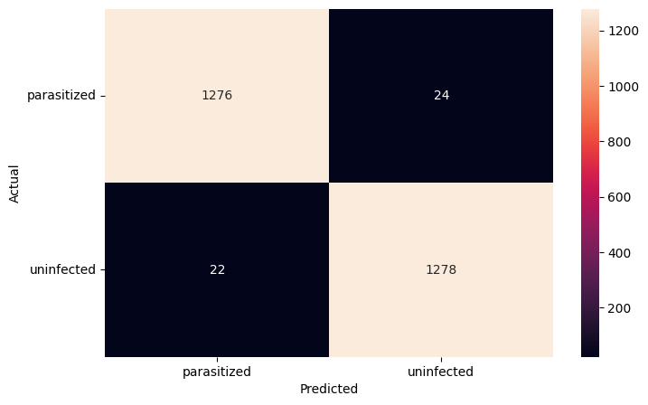

```python
plot_confusion_matrix(model1, gbx2, test_labels, CATEGORIES)
```

**Plotting the train and the validation curves**

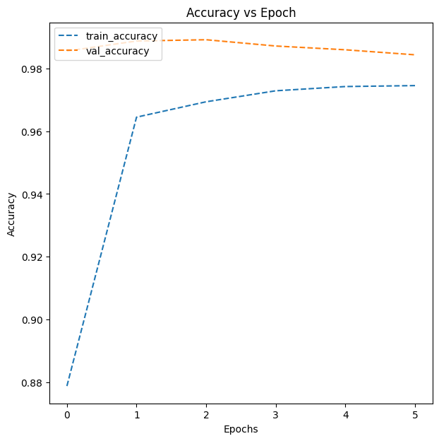

```python
plot_accuracy(history1)
```

Observations on Model 1:

Model1 is definitely better than base model as it has lower misclassificaitons and improved accuracy and recall and f score . Slightly lower validation loss

Better precision for both classes, meaning fewer false alarms

Lower false positives (less likely to misclassify healthy as infected)

98% recall meaning Of all the truly infected patients, 2% were missed and it also has lesser FP minimizing false alarms Hence, better than base model

From the accuracy plot of Model 1:

Validation accuracy starts to slightly decline after epoch 2–3 while training accuracy continues to rise.

This suggests overfitting, where the model learns the training data too well and loses generalization ability on unseen data.

So Lets try another model with batch normalization and leaky relu if that improves the results further

### **Think about it:**

Now let's build a model with LeakyRelu as the activation function

- Can the model performance be improved if we change our activation function to LeakyRelu?
- Can BatchNormalization improve our model?

Let us try to build a model using BatchNormalization and using LeakyRelu as our activation function.

**Batch Normalization:** Batch Normalization helps stabilize the training process by normalizing the activations within each layer. This can lead to faster convergence and improved generalization performance, which means the model is less likely to overfit and should perform better on unseen data.

**LeakyReLU Activation:** LeakyReLU is an improved version of the ReLU activation function. It addresses the "dying ReLU" problem by allowing a small, non-zero gradient for negative inputs. This can further enhance the model's learning ability.

### **Model 2 with Batch Normalization**

### **Building the Model2**

```python
clear_backend_gen_random_seed()
```

```python
from tensorflow.keras import layers, optimizers

model2 = Sequential()
model2.add(Conv2D(32, (3,3), input_shape=(64, 64, 3), padding='same'))
model2.add(LeakyReLU(0.1))
model2.add(Conv2D(32, (3,3),padding='same'))
model2.add(LeakyReLU(0.1))
model2.add(MaxPooling2D(pool_size=2))

model2.add(BatchNormalization())

model2.add(Conv2D(32, (3,3),  padding='same'))
model2.add(LeakyReLU(0.1))

model2.add(Conv2D(32, (3,3),  padding='same'))
model2.add(LeakyReLU(0.1))
model2.add(MaxPooling2D(pool_size=2))
model2.add(BatchNormalization())



model2.add(Flatten())

model2.add(Dense(512,activation="relu"))
model2.add(BatchNormalization())
model2.add(Dense(2,activation="softmax"))#2 represent output layer neurons

adam = optimizers.Adam(learning_rate=0.001)

model2.summary()
```

```
Model: "sequential"
```

```
┏━━━━━━━━━━━━━━━━━━━━━━━━━━━━━━━━━┳━━━━━━━━━━━━━━━━━━━━━━━━┳━━━━━━━━━━━━━━━┓
┃ Layer (type)                    ┃ Output Shape           ┃       Param # ┃
┡━━━━━━━━━━━━━━━━━━━━━━━━━━━━━━━━━╇━━━━━━━━━━━━━━━━━━━━━━━━╇━━━━━━━━━━━━━━━┩
│ conv2d (Conv2D)                 │ (None, 64, 64, 32)     │           896 │
├─────────────────────────────────┼────────────────────────┼───────────────┤
│ leaky_re_lu (LeakyReLU)         │ (None, 64, 64, 32)     │             0 │
├─────────────────────────────────┼────────────────────────┼───────────────┤
│ conv2d_1 (Conv2D)               │ (None, 64, 64, 32)     │         9,248 │
├─────────────────────────────────┼────────────────────────┼───────────────┤
│ leaky_re_lu_1 (LeakyReLU)       │ (None, 64, 64, 32)     │             0 │
├─────────────────────────────────┼────────────────────────┼───────────────┤
│ max_pooling2d (MaxPooling2D)    │ (None, 32, 32, 32)     │             0 │
├─────────────────────────────────┼────────────────────────┼───────────────┤
│ batch_normalization             │ (None, 32, 32, 32)     │           128 │
│ (BatchNormalization)            │                        │               │
├─────────────────────────────────┼────────────────────────┼───────────────┤
│ conv2d_2 (Conv2D)               │ (None, 32, 32, 32)     │         9,248 │
├─────────────────────────────────┼────────────────────────┼───────────────┤
│ leaky_re_lu_2 (LeakyReLU)       │ (None, 32, 32, 32)     │             0 │
├─────────────────────────────────┼────────────────────────┼───────────────┤
│ conv2d_3 (Conv2D)               │ (None, 32, 32, 32)     │         9,248 │
├─────────────────────────────────┼────────────────────────┼───────────────┤
│ leaky_re_lu_3 (LeakyReLU)       │ (None, 32, 32, 32)     │             0 │
├─────────────────────────────────┼────────────────────────┼───────────────┤
│ max_pooling2d_1 (MaxPooling2D)  │ (None, 16, 16, 32)     │             0 │
├─────────────────────────────────┼────────────────────────┼───────────────┤
│ batch_normalization_1           │ (None, 16, 16, 32)     │           128 │
│ (BatchNormalization)            │                        │               │
├─────────────────────────────────┼────────────────────────┼───────────────┤
│ flatten (Flatten)               │ (None, 8192)           │             0 │
├─────────────────────────────────┼────────────────────────┼───────────────┤
│ dense (Dense)                   │ (None, 512)            │     4,194,816 │
├─────────────────────────────────┼────────────────────────┼───────────────┤
│ batch_normalization_2           │ (None, 512)            │         2,048 │
│ (BatchNormalization)            │                        │               │
├─────────────────────────────────┼────────────────────────┼───────────────┤
│ dense_1 (Dense)                 │ (None, 2)              │         1,026 │
└─────────────────────────────────┴────────────────────────┴───────────────┘
```

```
 Total params: 4,226,786 (16.12 MB)
```

```
 Trainable params: 4,225,634 (16.12 MB)
```

```
 Non-trainable params: 1,152 (4.50 KB)
```

### **Compiling the model**

```python
# Compiling the model
model2.compile(optimizer = adam, loss = 'categorical_crossentropy', metrics = ['accuracy'])
```

**Using callbacks**

```python
es = EarlyStopping(monitor = 'val_loss', mode = 'min', verbose = 1, patience = 3, restore_best_weights=True)
mc = ModelCheckpoint('mdl2.keras', monitor = 'val_accuracy', mode = 'max', verbose = 1, save_best_only = True)
```

**Fit and train the model**

```python
history2  = model2.fit(gbx, train_labels,
                                      batch_size = 32,
                                      validation_split = 0.2,
                                      epochs = 25,
                                      verbose = 1,
                                      callbacks = [es,mc])
```

```
624/624 ━━━━━━━━━━━━━━━━━━━━ 0s 12ms/step - accuracy: 0.7412 - loss: 0.6147
Epoch 1: val_accuracy improved from -inf to 0.95072, saving model to mdl2.keras
624/624 ━━━━━━━━━━━━━━━━━━━━ 14s 16ms/step - accuracy: 0.7413 - loss: 0.6143 - val_accuracy: 0.9507 - val_loss: 0.1553
623/624 ━━━━━━━━━━━━━━━━━━━━ 0s 9ms/step - accuracy: 0.9427 - loss: 0.1604
Epoch 2: val_accuracy improved from 0.95072 to 0.97716, saving model to mdl2.keras
624/624 ━━━━━━━━━━━━━━━━━━━━ 7s 11ms/step - accuracy: 0.9427 - loss: 0.1603 - val_accuracy: 0.9772 - val_loss: 0.1084
620/624 ━━━━━━━━━━━━━━━━━━━━ 0s 10ms/step - accuracy: 0.9602 - loss: 0.1185
Epoch 3: val_accuracy improved from 0.97716 to 0.99119, saving model to mdl2.keras
624/624 ━━━━━━━━━━━━━━━━━━━━ 10s 11ms/step - accuracy: 0.9602 - loss: 0.1185 - val_accuracy: 0.9912 - val_loss: 0.0351
621/624 ━━━━━━━━━━━━━━━━━━━━ 0s 10ms/step - accuracy: 0.9692 - loss: 0.0904
Epoch 4: val_accuracy did not improve from 0.99119
624/624 ━━━━━━━━━━━━━━━━━━━━ 10s 11ms/step - accuracy: 0.9692 - loss: 0.0905 - val_accuracy: 0.9645 - val_loss: 0.1204
622/624 ━━━━━━━━━━━━━━━━━━━━ 0s 10ms/step - accuracy: 0.9740 - loss: 0.0752
Epoch 5: val_accuracy did not improve from 0.99119
624/624 ━━━━━━━━━━━━━━━━━━━━ 7s 11ms/step - accuracy: 0.9740 - loss: 0.0752 - val_accuracy: 0.9746 - val_loss: 0.0916
620/624 ━━━━━━━━━━━━━━━━━━━━ 0s 9ms/step - accuracy: 0.9773 - loss: 0.0648
Epoch 6: val_accuracy did not improve from 0.99119
624/624 ━━━━━━━━━━━━━━━━━━━━ 7s 10ms/step - accuracy: 0.9773 - loss: 0.0648 - val_accuracy: 0.9724 - val_loss: 0.1059
Epoch 6: early stopping
```

**Plotting the train and validation accuracy**

### **Evaluating the model**

```python
accuracy2 = model2.evaluate(gbx2, test_labels, verbose = 1)
```

```
82/82 ━━━━━━━━━━━━━━━━━━━━ 1s 9ms/step - accuracy: 0.9848 - loss: 0.0611
```

**Generate the classification report and confusion matrix**

```
82/82 ━━━━━━━━━━━━━━━━━━━━ 1s 8ms/step
              precision    recall  f1-score   support

           0       0.99      0.97      0.98      1300
           1       0.97      0.99      0.98      1300

    accuracy                           0.98      2600
   macro avg       0.98      0.98      0.98      2600
weighted avg       0.98      0.98      0.98      2600
```

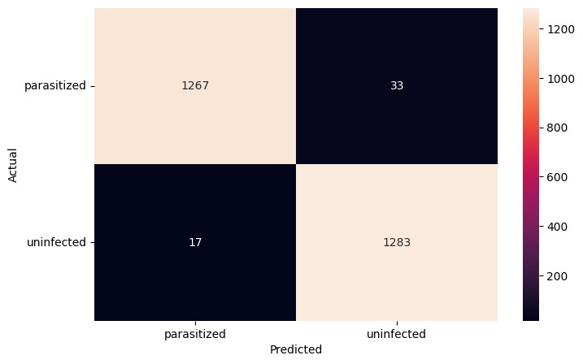

```python
plot_confusion_matrix(model2, gbx2, test_labels, CATEGORIES)
```

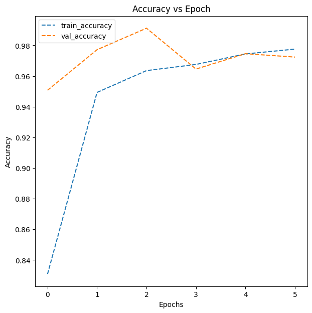

```python
plot_accuracy(history2)
```

```python
clear_backend_gen_random_seed()
```

### **Think About It :**

- Can we improve the model with Image Data Augmentation?
- References to image data augmentation can be seen below:
  - [Image Augmentation for Computer Vision](https://www.mygreatlearning.com/blog/understanding-data-augmentation/)
  - [How to Configure Image Data Augmentation in Keras?](https://machinelearningmastery.com/how-to-configure-image-data-augmentation-when-training-deep-learning-neural-networks/)

### **Use image data generator**

define the test and train generators that are used for real-time data augmentation and data feeding during model training.

seed 42 for reproducible results shuffle = true to shuffle the data batch_size = 32 standard batch size

```python
clear_backend_gen_random_seed()
```

```python
from sklearn.model_selection import train_test_split
from tensorflow.keras.preprocessing.image import ImageDataGenerator

X_train, X_val, y_train, y_val = train_test_split(train_images, train_labels, test_size=0.2, random_state=42)


# Using ImageDataGenerator to generate images

train_datagen = ImageDataGenerator(horizontal_flip=True,
                                  zoom_range = 0.5, rotation_range=20)
val_datagen  = ImageDataGenerator()

# Flowing training images using train_datagen generator
train_generator = train_datagen.flow(x = X_train, y = y_train, batch_size=32, seed=42, shuffle=True)

# Flowing validation images using val_datagen generator
val_generator =  val_datagen.flow(x= X_val, y = y_val, batch_size=32, seed=42, shuffle=True)
```

```python
validation_datagen = ImageDataGenerator()
```

### **Think About It :**

- Check if the performance of the model can be improved by changing different parameters in the ImageDataGenerator.

#### **Visualizing Augmented images**

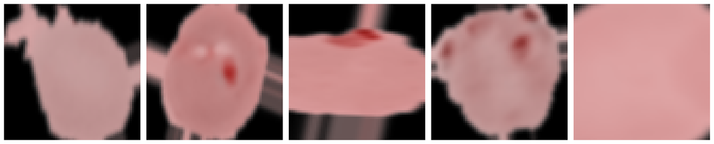

```python
# Prepare iterator including labels
it = train_datagen.flow(gbx, train_labels, batch_size=1)

# Create a figure and axes for the subplot
fig, axes = plt.subplots(1, 5, figsize=(18, 18))  # 1 row, 5 columns

# Visualize augmented images with corresponding labels
# Display a few augmented images in a single row
for i in range(5):
    image = next(it)[0]  # Get the next augmented image
    # Squeeze the image array to remove the batch size dimension
    image = image.squeeze(0)  # Reshape to (64, 64, 3)

    # Convert HSV to RGB if the image is in HSV format
    image = cv2.cvtColor(image, cv2.COLOR_HSV2RGB)

    # Normalize the image to 0-255 and convert to uint8
    image = (image * 255).astype('uint8')

    # Set aspect ratio to 'equal' to maintain original image proportions
    axes[i].imshow(image, aspect='equal')  # Display the image on the corresponding subplot
    axes[i].axis('off')  # Turn off axis labels and ticks

plt.tight_layout()  # Adjust subplot parameters for a tight layout
plt.show()  # Display the figure
```

#### **Observations and insights: ____**

From above we can see the following effects:

- The augmented images exhibit a good variety of transformations, including rotations, zooms, and horizontal flips.
- Stripes are most likely related to shifting the images The colors are different
- Some images are zoomed in or out, which introduces variations in the scale of the cells, making the model more robust to different magnifications.
- Despite the transformations, the key features of the cells, such as the presence or absence of parasites (the reddish-purple dots), appear to be preserved in the augmented images. This is crucial for the model to learn relevant patterns from the data.
- The augmented images generally look realistic and resemble actual microscopic images of blood cells. This ensures that the model is trained on data that is representative of the real-world scenarios it will encounter during inference.

### **Building the Model**

```python
clear_backend_gen_random_seed()
```

```python
model3 = Sequential()

# Build the model here
model3.add(Conv2D(32, (3,3), input_shape=(64, 64, 3), padding='same'))
model3.add(LeakyReLU(0.1))
model3.add(Conv2D(32, (3,3),padding='same'))
model3.add(LeakyReLU(0.1))
model3.add(MaxPooling2D(pool_size=2))

model3.add(BatchNormalization())

model3.add(Conv2D(32, (3,3),  padding='same'))
model3.add(LeakyReLU(0.1))

model3.add(Conv2D(32, (3,3),  padding='same'))
model3.add(LeakyReLU(0.1))
model3.add(MaxPooling2D(pool_size=2))
model3.add(BatchNormalization())



model3.add(Flatten())

model3.add(Dense(512))
model3.add(Dropout(0.2))
model3.add(Dense(2,activation="softmax"))#2 represent output layer neurons

# use this as the optimizer
adam = optimizers.Adam(learning_rate=0.001)
model3.compile(loss="binary_crossentropy", optimizer=adam, metrics = ['accuracy'])
model3.summary()
```

```
Model: "sequential"
```

```
┏━━━━━━━━━━━━━━━━━━━━━━━━━━━━━━━━━━━━━━┳━━━━━━━━━━━━━━━━━━━━━━━━━━━━━┳━━━━━━━━━━━━━━━━━┓
┃ Layer (type)                         ┃ Output Shape                ┃         Param # ┃
┡━━━━━━━━━━━━━━━━━━━━━━━━━━━━━━━━━━━━━━╇━━━━━━━━━━━━━━━━━━━━━━━━━━━━━╇━━━━━━━━━━━━━━━━━┩
│ conv2d (Conv2D)                      │ (None, 64, 64, 32)          │             896 │
├──────────────────────────────────────┼─────────────────────────────┼─────────────────┤
│ leaky_re_lu (LeakyReLU)              │ (None, 64, 64, 32)          │               0 │
├──────────────────────────────────────┼─────────────────────────────┼─────────────────┤
│ conv2d_1 (Conv2D)                    │ (None, 64, 64, 32)          │           9,248 │
├──────────────────────────────────────┼─────────────────────────────┼─────────────────┤
│ leaky_re_lu_1 (LeakyReLU)            │ (None, 64, 64, 32)          │               0 │
├──────────────────────────────────────┼─────────────────────────────┼─────────────────┤
│ max_pooling2d (MaxPooling2D)         │ (None, 32, 32, 32)          │               0 │
├──────────────────────────────────────┼─────────────────────────────┼─────────────────┤
│ batch_normalization                  │ (None, 32, 32, 32)          │             128 │
│ (BatchNormalization)                 │                             │                 │
├──────────────────────────────────────┼─────────────────────────────┼─────────────────┤
│ conv2d_2 (Conv2D)                    │ (None, 32, 32, 32)          │           9,248 │
├──────────────────────────────────────┼─────────────────────────────┼─────────────────┤
│ leaky_re_lu_2 (LeakyReLU)            │ (None, 32, 32, 32)          │               0 │
├──────────────────────────────────────┼─────────────────────────────┼─────────────────┤
│ conv2d_3 (Conv2D)                    │ (None, 32, 32, 32)          │           9,248 │
├──────────────────────────────────────┼─────────────────────────────┼─────────────────┤
│ leaky_re_lu_3 (LeakyReLU)            │ (None, 32, 32, 32)          │               0 │
├──────────────────────────────────────┼─────────────────────────────┼─────────────────┤
│ max_pooling2d_1 (MaxPooling2D)       │ (None, 16, 16, 32)          │               0 │
├──────────────────────────────────────┼─────────────────────────────┼─────────────────┤
│ batch_normalization_1                │ (None, 16, 16, 32)          │             128 │
│ (BatchNormalization)                 │                             │                 │
├──────────────────────────────────────┼─────────────────────────────┼─────────────────┤
│ flatten (Flatten)                    │ (None, 8192)                │               0 │
├──────────────────────────────────────┼─────────────────────────────┼─────────────────┤
│ dense (Dense)                        │ (None, 512)                 │       4,194,816 │
├──────────────────────────────────────┼─────────────────────────────┼─────────────────┤
│ dropout (Dropout)                    │ (None, 512)                 │               0 │
├──────────────────────────────────────┼─────────────────────────────┼─────────────────┤
│ dense_1 (Dense)                      │ (None, 2)                   │           1,026 │
└──────────────────────────────────────┴─────────────────────────────┴─────────────────┘
```

```
 Total params: 4,224,738 (16.12 MB)
```

```
 Trainable params: 4,224,610 (16.12 MB)
```

```
 Non-trainable params: 128 (512.00 B)
```

```python
# Compiling the model
model3.compile(optimizer = adam, loss = 'categorical_crossentropy', metrics = ['accuracy'])
```

**Using Callbacks**

```python
es = EarlyStopping(monitor = 'val_loss', mode = 'min', verbose = 1, patience = 3)
mc = ModelCheckpoint('mdl2.keras', monitor = 'val_accuracy', mode = 'max', verbose = 1, save_best_only = True)
```

**Fit and Train the model**

```python
history3  = model3.fit(gbx, train_labels,
                                      batch_size = 32,
                                      validation_split = 0.2,
                                      epochs = 25,
                                      verbose = 1,
                                      callbacks = [es,mc])
```

```
624/624 ━━━━━━━━━━━━━━━━━━━━ 0s 13ms/step - accuracy: 0.7038 - loss: 3.3466
Epoch 1: val_accuracy improved from -inf to 0.99439, saving model to mdl2.keras
624/624 ━━━━━━━━━━━━━━━━━━━━ 16s 16ms/step - accuracy: 0.7040 - loss: 3.3433 - val_accuracy: 0.9944 - val_loss: 0.0338
619/624 ━━━━━━━━━━━━━━━━━━━━ 0s 10ms/step - accuracy: 0.9369 - loss: 0.1787
Epoch 2: val_accuracy did not improve from 0.99439
624/624 ━━━━━━━━━━━━━━━━━━━━ 7s 10ms/step - accuracy: 0.9369 - loss: 0.1787 - val_accuracy: 0.9834 - val_loss: 0.0846
621/624 ━━━━━━━━━━━━━━━━━━━━ 0s 9ms/step - accuracy: 0.9556 - loss: 0.1271
Epoch 3: val_accuracy did not improve from 0.99439
624/624 ━━━━━━━━━━━━━━━━━━━━ 7s 12ms/step - accuracy: 0.9556 - loss: 0.1272 - val_accuracy: 0.9820 - val_loss: 0.0839
619/624 ━━━━━━━━━━━━━━━━━━━━ 0s 10ms/step - accuracy: 0.9638 - loss: 0.1082
Epoch 4: val_accuracy did not improve from 0.99439
624/624 ━━━━━━━━━━━━━━━━━━━━ 7s 10ms/step - accuracy: 0.9638 - loss: 0.1083 - val_accuracy: 0.9617 - val_loss: 0.1710
Epoch 4: early stopping
```

### **Evaluating the model**

**Plot the train and validation accuracy**

```python
 # Model accuracy
model3.evaluate(gbx2, (test_labels))
```

```
82/82 ━━━━━━━━━━━━━━━━━━━━ 1s 8ms/step - accuracy: 0.9797 - loss: 0.0596
```

```
[0.08663549274206161, 0.9761538505554199]
```

**Plotting the classification report and confusion matrix**

```
82/82 ━━━━━━━━━━━━━━━━━━━━ 0s 4ms/step
              precision    recall  f1-score   support

           0       0.97      0.98      0.98      1300
           1       0.98      0.97      0.98      1300

    accuracy                           0.98      2600
   macro avg       0.98      0.98      0.98      2600
weighted avg       0.98      0.98      0.98      2600
```

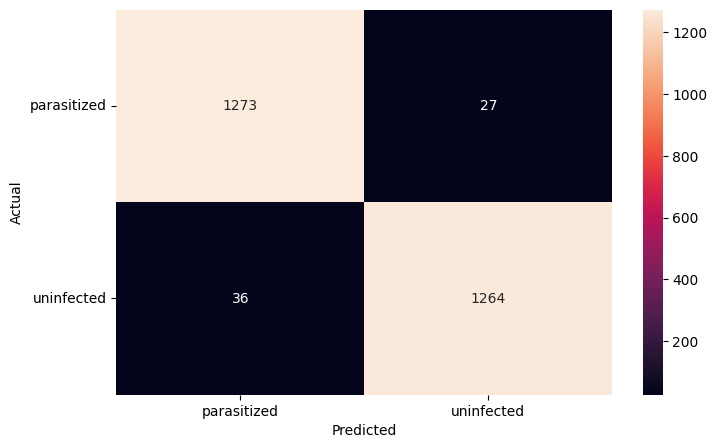

```python
plot_confusion_matrix(model3, gbx2, test_labels, CATEGORIES)
```

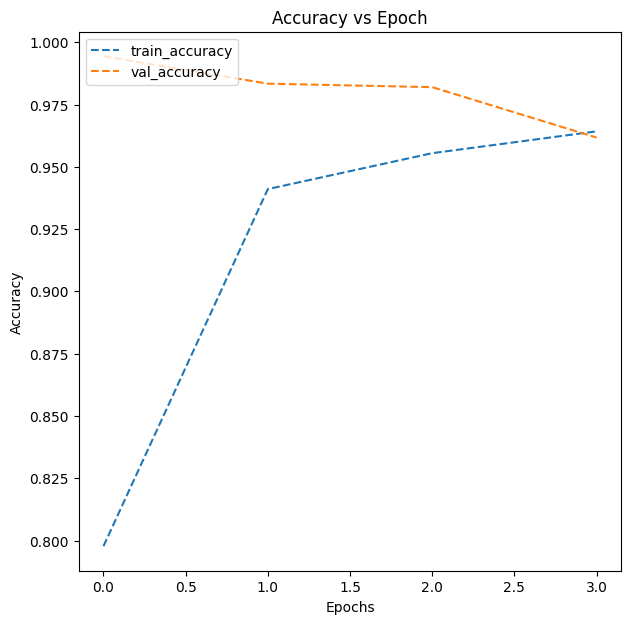

```python
plot_accuracy(history3)
```

Although it is a good model , Accuracy of this models drops to ~97%. Model 3 has a very high initial validation accuracy but drops sooner than model2. This suggests overfitting kicks in quicker, possibly due to fewer regularization techniques or a simpler architecture.

Model 2 sustains better performance over more epochs and finishes with slightly better training and validation accuracy. Model 2 seems more robust in generalization over time.

**Now, let us try to use a pretrained model like VGG16 and check how it performs on our data.**

### **Pre-trained model (VGG16) with Transfer Learning & Data Augmentation**

- Import VGG16 network upto any layer you choose
- Add Fully Connected Layers on top of it

```python
clear_backend_gen_random_seed()
```

```python
from tensorflow.keras import Model
from tensorflow.keras.applications.vgg16 import VGG16
from sklearn.model_selection import train_test_split
```

```python
#Resize images in batches to (32,32,3) as VGG16 accepts data in that format

def resize_in_batches(images, batch_size, normalize=True, IMG_SIZE=32):
    num_samples = len(images)
    num_batches = num_samples // batch_size
    remaining_samples = num_samples % batch_size

    resized_images = []

    # Process full batches
    for i in range(num_batches):
        batch = images[i * batch_size : (i + 1) * batch_size]
        batch_resized = [cv2.resize(img, (IMG_SIZE, IMG_SIZE)) for img in batch]
        resized_images.extend(batch_resized)

    # Process remaining images
    if remaining_samples > 0:
        remaining_batch = images[num_batches * batch_size :]
        remaining_resized_batch = [
            cv2.resize(img, (IMG_SIZE, IMG_SIZE)) for img in remaining_batch
        ]
        resized_images.extend(remaining_resized_batch)

    resized_images = np.array(resized_images)

    if normalize:
        resized_images = resized_images / 255.0  # Normalize pixel values to [0, 1]

    return resized_images.astype("float32")

# Resize training and test images
X_train_resized = resize_in_batches(gbx, batch_size=32, normalize=False, IMG_SIZE=32)
X_test_resized = resize_in_batches(gbx2, batch_size=32, normalize=False, IMG_SIZE=32)
```

```python
# Split training data into training and validation sets
X_train, X_val, y_train, y_val = train_test_split(
    X_train_resized, train_labels, test_size=0.2, random_state=42
)
```

```python
#Data Augmentation
from tensorflow.keras.preprocessing.image import ImageDataGenerator
train_datagen = ImageDataGenerator(
    horizontal_flip=True, zoom_range=0.5, rotation_range=20
)
val_datagen = ImageDataGenerator()

train_generator = train_datagen.flow(
    X_train, y_train, batch_size=32, seed=42, shuffle=True
)
val_generator = val_datagen.flow(X_val, y_val, batch_size=32, seed=42, shuffle=True)
```

### **Compiling the model**

```python
# Load the pre-trained VGG16 model (excluding the top classification layers)
base_model = VGG16(weights='imagenet', include_top=False, input_shape=(32, 32, 3))

# Freeze the layers in the base model
for layer in base_model.layers:
    layer.trainable = False

# Add new classification layers on top
x = base_model.output
x = Flatten()(x)
x = Dense(512, activation='relu')(x)
predictions = Dense(2, activation='softmax')(x)  # 2 classes for malaria detection

model_vgg16 = Model(inputs=base_model.input, outputs=predictions)

# Compile the model
model_vgg16.compile(optimizer='adam', loss='categorical_crossentropy', metrics=['accuracy'])

# Print model summary
model_vgg16.summary()
```

```
Model: "functional"
```

```
┏━━━━━━━━━━━━━━━━━━━━━━━━━━━━━━━━━━━━━━┳━━━━━━━━━━━━━━━━━━━━━━━━━━━━━┳━━━━━━━━━━━━━━━━━┓
┃ Layer (type)                         ┃ Output Shape                ┃         Param # ┃
┡━━━━━━━━━━━━━━━━━━━━━━━━━━━━━━━━━━━━━━╇━━━━━━━━━━━━━━━━━━━━━━━━━━━━━╇━━━━━━━━━━━━━━━━━┩
│ input_layer (InputLayer)             │ (None, 32, 32, 3)           │               0 │
├──────────────────────────────────────┼─────────────────────────────┼─────────────────┤
│ block1_conv1 (Conv2D)                │ (None, 32, 32, 64)          │           1,792 │
├──────────────────────────────────────┼─────────────────────────────┼─────────────────┤
│ block1_conv2 (Conv2D)                │ (None, 32, 32, 64)          │          36,928 │
├──────────────────────────────────────┼─────────────────────────────┼─────────────────┤
│ block1_pool (MaxPooling2D)           │ (None, 16, 16, 64)          │               0 │
├──────────────────────────────────────┼─────────────────────────────┼─────────────────┤
│ block2_conv1 (Conv2D)                │ (None, 16, 16, 128)         │          73,856 │
├──────────────────────────────────────┼─────────────────────────────┼─────────────────┤
│ block2_conv2 (Conv2D)                │ (None, 16, 16, 128)         │         147,584 │
├──────────────────────────────────────┼─────────────────────────────┼─────────────────┤
│ block2_pool (MaxPooling2D)           │ (None, 8, 8, 128)           │               0 │
├──────────────────────────────────────┼─────────────────────────────┼─────────────────┤
│ block3_conv1 (Conv2D)                │ (None, 8, 8, 256)           │         295,168 │
├──────────────────────────────────────┼─────────────────────────────┼─────────────────┤
│ block3_conv2 (Conv2D)                │ (None, 8, 8, 256)           │         590,080 │
├──────────────────────────────────────┼─────────────────────────────┼─────────────────┤
│ block3_conv3 (Conv2D)                │ (None, 8, 8, 256)           │         590,080 │
├──────────────────────────────────────┼─────────────────────────────┼─────────────────┤
│ block3_pool (MaxPooling2D)           │ (None, 4, 4, 256)           │               0 │
├──────────────────────────────────────┼─────────────────────────────┼─────────────────┤
│ block4_conv1 (Conv2D)                │ (None, 4, 4, 512)           │       1,180,160 │
├──────────────────────────────────────┼─────────────────────────────┼─────────────────┤
│ block4_conv2 (Conv2D)                │ (None, 4, 4, 512)           │       2,359,808 │
├──────────────────────────────────────┼─────────────────────────────┼─────────────────┤
│ block4_conv3 (Conv2D)                │ (None, 4, 4, 512)           │       2,359,808 │
├──────────────────────────────────────┼─────────────────────────────┼─────────────────┤
│ block4_pool (MaxPooling2D)           │ (None, 2, 2, 512)           │               0 │
├──────────────────────────────────────┼─────────────────────────────┼─────────────────┤
│ block5_conv1 (Conv2D)                │ (None, 2, 2, 512)           │       2,359,808 │
├──────────────────────────────────────┼─────────────────────────────┼─────────────────┤
│ block5_conv2 (Conv2D)                │ (None, 2, 2, 512)           │       2,359,808 │
├──────────────────────────────────────┼─────────────────────────────┼─────────────────┤
│ block5_conv3 (Conv2D)                │ (None, 2, 2, 512)           │       2,359,808 │
├──────────────────────────────────────┼─────────────────────────────┼─────────────────┤
│ block5_pool (MaxPooling2D)           │ (None, 1, 1, 512)           │               0 │
├──────────────────────────────────────┼─────────────────────────────┼─────────────────┤
│ flatten (Flatten)                    │ (None, 512)                 │               0 │
├──────────────────────────────────────┼─────────────────────────────┼─────────────────┤
│ dense (Dense)                        │ (None, 512)                 │         262,656 │
├──────────────────────────────────────┼─────────────────────────────┼─────────────────┤
│ dense_1 (Dense)                      │ (None, 2)                   │           1,026 │
└──────────────────────────────────────┴─────────────────────────────┴─────────────────┘
```

```
 Total params: 14,978,370 (57.14 MB)
```

```
 Trainable params: 263,682 (1.01 MB)
```

```
 Non-trainable params: 14,714,688 (56.13 MB)
```

**using callbacks**

```python
es = EarlyStopping(monitor="val_loss", mode="min", verbose=1, patience=3)
mc = ModelCheckpoint(
    "vgg16_model.keras", monitor="val_accuracy", mode="max", verbose=1, save_best_only=True
)
```

**Fit and Train the model**

```python
history_vgg16 = model_vgg16.fit(
    train_generator,  # Your training data generator
    epochs=10,  # Adjust the number of epochs as needed
    validation_data=val_generator  # Your validation data generator
)
```

```
624/624 ━━━━━━━━━━━━━━━━━━━━ 17s 25ms/step - accuracy: 0.7026 - loss: 0.5683 - val_accuracy: 0.7638 - val_loss: 0.4761
624/624 ━━━━━━━━━━━━━━━━━━━━ 14s 23ms/step - accuracy: 0.7590 - loss: 0.4915 - val_accuracy: 0.8067 - val_loss: 0.4479
624/624 ━━━━━━━━━━━━━━━━━━━━ 14s 23ms/step - accuracy: 0.7657 - loss: 0.4810 - val_accuracy: 0.8109 - val_loss: 0.4204
624/624 ━━━━━━━━━━━━━━━━━━━━ 14s 22ms/step - accuracy: 0.7755 - loss: 0.4642 - val_accuracy: 0.8167 - val_loss: 0.4094
624/624 ━━━━━━━━━━━━━━━━━━━━ 15s 24ms/step - accuracy: 0.7795 - loss: 0.4581 - val_accuracy: 0.7863 - val_loss: 0.4749
624/624 ━━━━━━━━━━━━━━━━━━━━ 14s 22ms/step - accuracy: 0.7793 - loss: 0.4588 - val_accuracy: 0.8123 - val_loss: 0.4019
624/624 ━━━━━━━━━━━━━━━━━━━━ 14s 22ms/step - accuracy: 0.7802 - loss: 0.4506 - val_accuracy: 0.8111 - val_loss: 0.4069
624/624 ━━━━━━━━━━━━━━━━━━━━ 14s 22ms/step - accuracy: 0.7858 - loss: 0.4469 - val_accuracy: 0.8197 - val_loss: 0.3985
624/624 ━━━━━━━━━━━━━━━━━━━━ 14s 22ms/step - accuracy: 0.7944 - loss: 0.4361 - val_accuracy: 0.8251 - val_loss: 0.3944
624/624 ━━━━━━━━━━━━━━━━━━━━ 14s 22ms/step - accuracy: 0.7861 - loss: 0.4453 - val_accuracy: 0.8229 - val_loss: 0.3955
```

**Plot the train and validation accuracy**

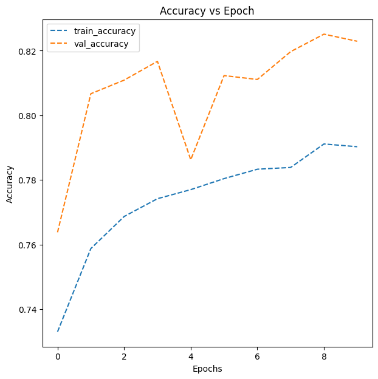

```python
plot_accuracy(history_vgg16)
```

### **Evaluating the model**

```python
 # Model accuracy
accuracy_vgg16 = model_vgg16.evaluate(X_test_resized, test_labels, verbose=1)
print("\n", "Test_Accuracy:", accuracy_vgg16[1])
```

```
82/82 ━━━━━━━━━━━━━━━━━━━━ 2s 15ms/step - accuracy: 0.8398 - loss: 0.3793

 Test_Accuracy: 0.7892307639122009
```

1. The validation accuracy is 0.83, which is very low compared to models 1 and 2. Validation accuracy is consistently higher than training accuracy maintaining a big gap. This suggests that training is harder for the model
2. Learning rate is a bit high, causing fluctuations.
3. Augmentation must have added noise
4. Training accuracy is increasing gradually and hasn't plateaued. More epochs might helkp but this would further raise already high computation cost of this model

**Plotting the classification report and confusion matrix**

```
82/82 ━━━━━━━━━━━━━━━━━━━━ 2s 15ms/step
              precision    recall  f1-score   support

           0       0.85      0.73      0.78      1300
           1       0.76      0.87      0.81      1300

    accuracy                           0.80      2600
   macro avg       0.80      0.80      0.80      2600
weighted avg       0.80      0.80      0.80      2600
```

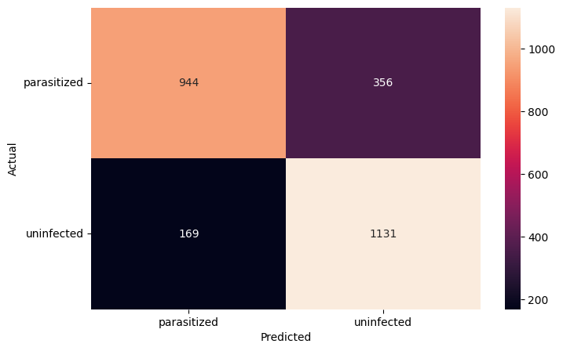

```python
plot_confusion_matrix(model_vgg16, X_test_resized, test_labels, CATEGORIES)
```

### **Observations and insights: _____**

- What can be observed from the validation and train curves?

**Improvements that can be done:**

- Can the model performance be improved using other pre-trained models or different CNN architecture?
- You can try to build a model using these HSV images and compare them with your other models.

# Model with Pretrained InceptionV3 CNN

```python
clear_backend_gen_random_seed()
```

```python
from sklearn.model_selection import train_test_split
from tensorflow.keras.preprocessing.image import ImageDataGenerator


X_train, X_val, y_train, y_val = train_test_split(gbx, train_labels, test_size=0.2, random_state=42)

# Using ImageDataGenerator to generate images


# Add Noise
def add_noise(img):
    VARIABILITY = 0.1 # customize this
    deviation = VARIABILITY*np.random.random()
    noise = np.random.normal(0, deviation, img.shape)
    img += noise
    #img = np.clip(img, 0., 255.)
    return img

datagen_aug = ImageDataGenerator(
      rescale=1./255,
      # customize these and other parameters
      rotation_range=45,
      width_shift_range=0.2,
      height_shift_range=0.2,
      shear_range=0,
      zoom_range=0,
      #preprocessing_function=add_noise,
      horizontal_flip=True,
      fill_mode='nearest',
)

val_datagen  = ImageDataGenerator(rescale=1./255)

# Resize images in X_train and X_val
X_train_resized = np.array([tf.image.resize(img, (75, 75)).numpy() for img in X_train])
X_val_resized = np.array([tf.image.resize(img, (75, 75)).numpy() for img in X_val])


# Flowing training images using train_datagen generator
train_generator = datagen_aug.flow(
    x = X_train_resized,
     y = y_train,
    batch_size=64,
    seed=42,
    shuffle=True,

)

# Flowing validation images using val_datagen generator
val_generator = val_datagen.flow(
    x=X_val_resized,
    y = y_val,
    batch_size=64,
    seed=42,
    shuffle=True,

)
```

```python
#Loading the Base Model

from tensorflow.keras.applications.inception_v3 import InceptionV3
base_model = InceptionV3(input_shape = (75, 75, 3), include_top = False, weights = 'imagenet')
```

```python
#Compile and Fit


for layer in base_model.layers:
    layer.trainable = False
```

```python
from tensorflow.keras import layers
from tensorflow.keras.optimizers import RMSprop

x = layers.Flatten()(base_model.output)
x = layers.Dense(256, activation='relu')(x)

x = layers.Dense(128, activation='relu')(x)
x = layers.Dropout(0.3)(x)

x = layers.Dense(64, activation='relu')(x)


# Add a final sigmoid layer with 2 node for classification output
x = layers.Dense(2, activation='sigmoid')(x)

model_inception = tf.keras.models.Model(base_model.input, x)
```

```python
  model_inception.compile(loss='categorical_crossentropy',
                optimizer=Adam(learning_rate=0.001),
                metrics=['accuracy'])
```

```python
model_inception.summary()
```

```
Model: "functional"
```

```
┏━━━━━━━━━━━━━━━━━━━━━━━━━━━┳━━━━━━━━━━━━━━━━━━━━━━━━┳━━━━━━━━━━━━━━━━┳━━━━━━━━━━━━━━━━━━━━━━━━┓
┃ Layer (type)              ┃ Output Shape           ┃        Param # ┃ Connected to           ┃
┡━━━━━━━━━━━━━━━━━━━━━━━━━━━╇━━━━━━━━━━━━━━━━━━━━━━━━╇━━━━━━━━━━━━━━━━╇━━━━━━━━━━━━━━━━━━━━━━━━┩
│ input_layer_2             │ (None, 75, 75, 3)      │              0 │ -                      │
│ (InputLayer)              │                        │                │                        │
├───────────────────────────┼────────────────────────┼────────────────┼────────────────────────┤
│ conv2d_188 (Conv2D)       │ (None, 37, 37, 32)     │            864 │ input_layer_2[0][0]    │
├───────────────────────────┼────────────────────────┼────────────────┼────────────────────────┤
│ batch_normalization_188   │ (None, 37, 37, 32)     │             96 │ conv2d_188[0][0]       │
│ (BatchNormalization)      │                        │                │                        │
├───────────────────────────┼────────────────────────┼────────────────┼────────────────────────┤
│ activation_188            │ (None, 37, 37, 32)     │              0 │ batch_normalization_1… │
│ (Activation)              │                        │                │                        │
├───────────────────────────┼────────────────────────┼────────────────┼────────────────────────┤
│ conv2d_189 (Conv2D)       │ (None, 35, 35, 32)     │          9,216 │ activation_188[0][0]   │
├───────────────────────────┼────────────────────────┼────────────────┼────────────────────────┤
│ batch_normalization_189   │ (None, 35, 35, 32)     │             96 │ conv2d_189[0][0]       │
│ (BatchNormalization)      │                        │                │                        │
├───────────────────────────┼────────────────────────┼────────────────┼────────────────────────┤
│ activation_189            │ (None, 35, 35, 32)     │              0 │ batch_normalization_1… │
│ (Activation)              │                        │                │                        │
├───────────────────────────┼────────────────────────┼────────────────┼────────────────────────┤
│ conv2d_190 (Conv2D)       │ (None, 35, 35, 64)     │         18,432 │ activation_189[0][0]   │
├───────────────────────────┼────────────────────────┼────────────────┼────────────────────────┤
│ batch_normalization_190   │ (None, 35, 35, 64)     │            192 │ conv2d_190[0][0]       │
│ (BatchNormalization)      │                        │                │                        │
├───────────────────────────┼────────────────────────┼────────────────┼────────────────────────┤
│ activation_190            │ (None, 35, 35, 64)     │              0 │ batch_normalization_1… │
│ (Activation)              │                        │                │                        │
├───────────────────────────┼────────────────────────┼────────────────┼────────────────────────┤
│ max_pooling2d_8           │ (None, 17, 17, 64)     │              0 │ activation_190[0][0]   │
│ (MaxPooling2D)            │                        │                │                        │
├───────────────────────────┼────────────────────────┼────────────────┼────────────────────────┤
│ conv2d_191 (Conv2D)       │ (None, 17, 17, 80)     │          5,120 │ max_pooling2d_8[0][0]  │
├───────────────────────────┼────────────────────────┼────────────────┼────────────────────────┤
│ batch_normalization_191   │ (None, 17, 17, 80)     │            240 │ conv2d_191[0][0]       │
│ (BatchNormalization)      │                        │                │                        │
├───────────────────────────┼────────────────────────┼────────────────┼────────────────────────┤
│ activation_191            │ (None, 17, 17, 80)     │              0 │ batch_normalization_1… │
│ (Activation)              │                        │                │                        │
```

[output cut: 819 more lines]

```
│                           │                        │                │ concatenate_5[0][0],   │
│                           │                        │                │ activation_281[0][0]   │
├───────────────────────────┼────────────────────────┼────────────────┼────────────────────────┤
│ flatten (Flatten)         │ (None, 2048)           │              0 │ mixed10[0][0]          │
├───────────────────────────┼────────────────────────┼────────────────┼────────────────────────┤
│ dense (Dense)             │ (None, 256)            │        524,544 │ flatten[0][0]          │
├───────────────────────────┼────────────────────────┼────────────────┼────────────────────────┤
│ dense_1 (Dense)           │ (None, 128)            │         32,896 │ dense[0][0]            │
├───────────────────────────┼────────────────────────┼────────────────┼────────────────────────┤
│ dropout (Dropout)         │ (None, 128)            │              0 │ dense_1[0][0]          │
├───────────────────────────┼────────────────────────┼────────────────┼────────────────────────┤
│ dense_2 (Dense)           │ (None, 64)             │          8,256 │ dropout[0][0]          │
├───────────────────────────┼────────────────────────┼────────────────┼────────────────────────┤
│ dense_3 (Dense)           │ (None, 2)              │            130 │ dense_2[0][0]          │
└───────────────────────────┴────────────────────────┴────────────────┴────────────────────────┘
```

```
 Total params: 23,500,264 (89.65 MB)
```

```
 Trainable params: 565,826 (2.16 MB)
```

```
 Non-trainable params: 21,802,784 (83.17 MB)
```

```
 Optimizer params: 1,131,654 (4.32 MB)
```

```python
  history_inception = model_inception.fit(
            train_generator, validation_data=val_generator,
            epochs=10,
            verbose=2
  )
```

```
312/312 - 66s - 212ms/step - accuracy: 0.5390 - loss: 0.7016 - val_accuracy: 0.5915 - val_loss: 0.6460
312/312 - 33s - 105ms/step - accuracy: 0.6599 - loss: 0.6258 - val_accuracy: 0.6508 - val_loss: 0.6280
312/312 - 34s - 109ms/step - accuracy: 0.6947 - loss: 0.5956 - val_accuracy: 0.7113 - val_loss: 0.5682
312/312 - 34s - 108ms/step - accuracy: 0.7102 - loss: 0.5743 - val_accuracy: 0.7015 - val_loss: 0.5878
312/312 - 34s - 108ms/step - accuracy: 0.7092 - loss: 0.5777 - val_accuracy: 0.7031 - val_loss: 0.5871
312/312 - 34s - 109ms/step - accuracy: 0.7079 - loss: 0.5721 - val_accuracy: 0.7378 - val_loss: 0.5492
312/312 - 33s - 105ms/step - accuracy: 0.7202 - loss: 0.5588 - val_accuracy: 0.7260 - val_loss: 0.5562
312/312 - 34s - 108ms/step - accuracy: 0.7126 - loss: 0.5731 - val_accuracy: 0.7378 - val_loss: 0.5352
312/312 - 34s - 108ms/step - accuracy: 0.7220 - loss: 0.5593 - val_accuracy: 0.6222 - val_loss: 0.6383
312/312 - 33s - 107ms/step - accuracy: 0.7213 - loss: 0.5575 - val_accuracy: 0.7366 - val_loss: 0.5351
```

```python
model_inception.evaluate(X_val_resized, y_val)
```

```
156/156 ━━━━━━━━━━━━━━━━━━━━ 8s 16ms/step - accuracy: 0.4530 - loss: 4.3874
```

```
[4.355313301086426, 0.44871795177459717]
```

```
156/156 ━━━━━━━━━━━━━━━━━━━━ 2s 15ms/step
              precision    recall  f1-score   support

           0       0.46      0.73      0.57      2442
           1       0.41      0.18      0.25      2550

    accuracy                           0.45      4992
   macro avg       0.43      0.45      0.41      4992
weighted avg       0.43      0.45      0.40      4992
```

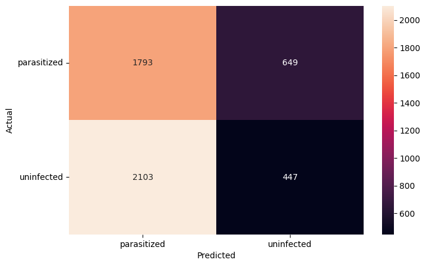

```python
plot_confusion_matrix(model_inception, X_val_resized, y_val, CATEGORIES)
```

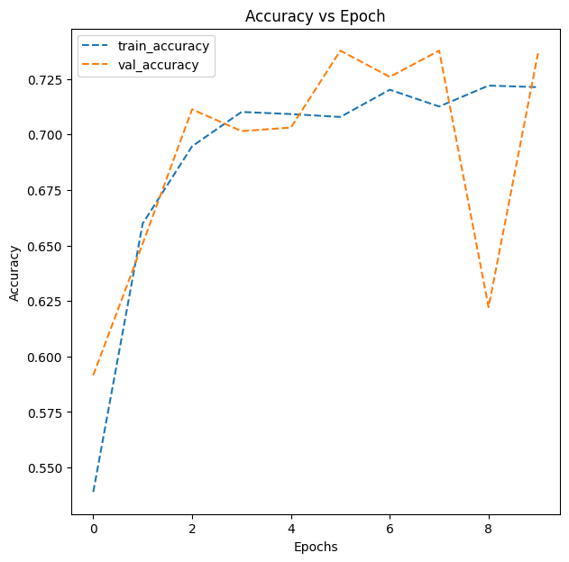

```python
plot_accuracy(history_inception)
```

Accuracy: 45.3% — that’s quite low for a classification task, especially given earlier models that hit ~97%. So this is not acceptable model and accuracy could not be improved with this transfer learning.

To see if model performace can be improved using different architecture lets use Keras tuner to generate models with different architecture and return best performing model on validation data. Lets try KEras tuner

# Optimized Architectures with Keras Tuner

```python
clear_backend_gen_random_seed
```

```
clear_backend_gen_random_seed
def clear_backend_gen_random_seed()
```

```
/content/<ipython-input-22-888f01dc108a><no docstring>
```

```python
!pip install keras-tuner
```

```
Downloading keras_tuner-1.4.7-py3-none-any.whl (129 kB)
   ━━━━━━━━━━━━━━━━━━━━━━━━━━━━━━━━━━━━━━━━ 129.1/129.1 kB 8.6 MB/s eta 0:00:00
Downloading kt_legacy-1.0.5-py3-none-any.whl (9.6 kB)
```

```python
def build_keras_tuner_model(hp):

    # Define Activation Function
    activation_f = LeakyReLU(0.1)

    # creating sequential model
    model4 = keras.Sequential()

    # First Convolutional layer with 32 filters and kernel size of 2. Use the 'same' padding and input shape of 64*64*3
    model4.add(Conv2D(32, (3,3), input_shape=(64, 64, 3), padding='same', activation=activation_f))

    # max-pooling layer with a pool size of 2
    model4.add(MaxPooling2D(pool_size=2))

    # Add dropout to randomly switch off 20% neurons to reduce overfitting
    model4.add(Dropout(0.2))

    # Flatten the output from the previous layer
    model4.add(Flatten())

    # Hidden Layers:
    # Tune the number of hidden layers and units in each.
    # Number of hidden layers: 1 - 5
    # Number of Units: 32 - 512 with stepsize of 32
    for i in range(1, hp.Int("num_layers", 2, 6)):
        model4.add(
            keras.layers.Dense(
                units=hp.Int("units_" + str(i), min_value=32, max_value=512, step=32),
                activation="relu")
            )

        # Tune dropout layer with values from 0 - 0.3 with stepsize of 0.1.
        model4.add(keras.layers.Dropout(hp.Float("dropout_" + str(i), 0, 0.3, step=0.1)))

    # Add output layer.
    model4.add(keras.layers.Dense(units=2, activation="softmax"))

    # Tune learning rate for Adam optimizer with values from 0.01, 0.001, or 0.0001
    hp_learning_rate = hp.Choice("learning_rate", values=[1e-2, 1e-3, 1e-4])


    model4.compile(optimizer=keras.optimizers.Adam(learning_rate=hp_learning_rate),
                  loss="binary_crossentropy",
                  metrics=["accuracy"])


    return model4
```

```python
import keras_tuner as kt
import keras  # Import keras inside the function
from tensorflow.keras import layers, optimizers
from tensorflow.keras.layers import LeakyReLU, Conv2D, MaxPooling2D, Flatten, Dropout, Dense, BatchNormalization

tuner = kt.RandomSearch(build_keras_tuner_model,
                     objective="val_accuracy",
                     max_trials=7
                     )
tuner.search(gbx, train_labels, epochs=5, validation_data=(gbx2, test_labels)) # Added validation_data
```

```
Trial 7 Complete [00h 00m 48s]
val_accuracy: 0.5

Best val_accuracy So Far: 0.9300000071525574
Total elapsed time: 00h 05m 41s
```

```python
es = EarlyStopping(monitor="val_loss", mode="min", verbose=1, patience=3)
mc = ModelCheckpoint(
    "model4.keras", monitor="val_accuracy", mode="max", verbose=1, save_best_only=True
)
```

```python
# After the search, access the best hyperparameters
best_hps=tuner.get_best_hyperparameters()[0]

# Build model
model4 = tuner.hypermodel.build(best_hps)
# Get the optimal hyperparameters from the results
best_hps=tuner.get_best_hyperparameters()[0]

# Build model
model4 = tuner.hypermodel.build(best_hps)

# Train the hypertuned model
history4 = model4.fit(gbx, train_labels, epochs=5, validation_data=(gbx2, test_labels), callbacks=[es, mc], verbose=2)
```

```
Epoch 1: val_accuracy improved from -inf to 0.71615, saving model to model4.keras
780/780 - 12s - 15ms/step - accuracy: 0.7284 - loss: 0.5338 - val_accuracy: 0.7162 - val_loss: 0.4997

Epoch 2: val_accuracy improved from 0.71615 to 0.81538, saving model to model4.keras
780/780 - 5s - 7ms/step - accuracy: 0.8251 - loss: 0.3900 - val_accuracy: 0.8154 - val_loss: 0.3725

Epoch 3: val_accuracy improved from 0.81538 to 0.87000, saving model to model4.keras
780/780 - 6s - 7ms/step - accuracy: 0.8871 - loss: 0.2733 - val_accuracy: 0.8700 - val_loss: 0.3080

Epoch 4: val_accuracy did not improve from 0.87000
780/780 - 5s - 6ms/step - accuracy: 0.9107 - loss: 0.2228 - val_accuracy: 0.8677 - val_loss: 0.2986

Epoch 5: val_accuracy improved from 0.87000 to 0.88115, saving model to model4.keras
780/780 - 5s - 7ms/step - accuracy: 0.9247 - loss: 0.1917 - val_accuracy: 0.8812 - val_loss: 0.2858
```

```python
model4.evaluate(gbx2, (test_labels))
```

```
82/82 ━━━━━━━━━━━━━━━━━━━━ 0s 3ms/step - accuracy: 0.8985 - loss: 0.2820
```

```
[0.2857794761657715, 0.8811538219451904]
```

```
82/82 ━━━━━━━━━━━━━━━━━━━━ 1s 6ms/step
              precision    recall  f1-score   support

           0       0.90      0.85      0.88      1300
           1       0.86      0.91      0.88      1300

    accuracy                           0.88      2600
   macro avg       0.88      0.88      0.88      2600
weighted avg       0.88      0.88      0.88      2600
```

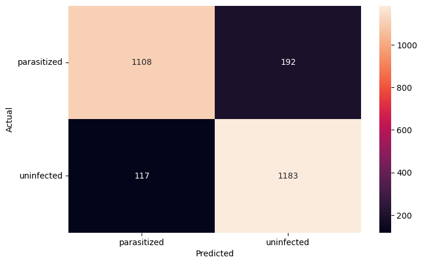

```python
plot_confusion_matrix(model4, gbx2, test_labels, CATEGORIES)
```

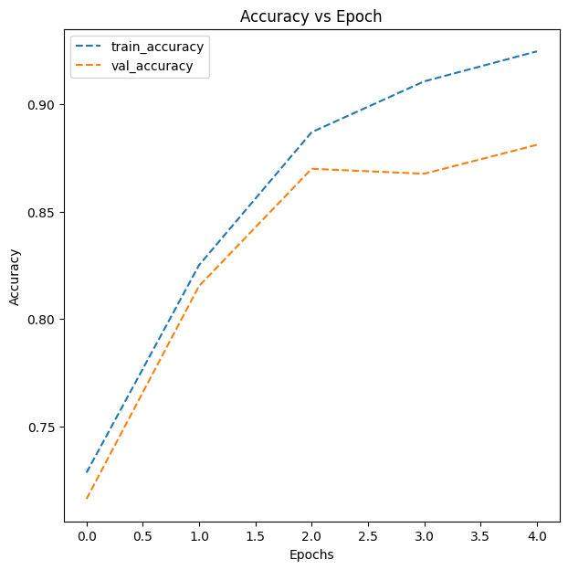

```python
plot_accuracy(history4)
```

### **Think about it:**

- What observations and insights can be drawn from the confusion matrix and classification report?
1. Overall accuracy is **~89%**indicating that the model is learning well and generalizing to unseen data. But still **model2 outperforms** with its higher accuracy of 98%
2. The training accuracy is slightly higher than validation accuracy, which is expected, but the difference is not too significant, suggesting that overfitting is not a major issue.

### **Think about it:**

- Choose the model with the best accuracy scores from all the above models and save it as a final model.

**MODEL2** is the best model

[figure not shown]

**Why choose model2 amongst model1 and model2 :**

Models developed :

1. **Model ( base_model)** – 3 convolutional layer and 1,058,786 trainable parameters and drop out. The base model is likely overfitting the training data, leading to poor generalization performance on the test set. It also seems to have a bias towards class 0, resulting in lower recall for class 1
2. **Model1** – have 4 convolutional layers and Trainable params: 276,482. It is good performing model with high training and validation accuracy of 0.98. The precision, recall, and F1-score are very similar for both classes (0 and 1), suggesting that the model performs equally well on both types of cells. There is slight overfitting, but the overfitting appears to be minimal and doesn't significantly impact the model's overall performance. Compared to the base model, model1 shows substantial improvement in accuracy, precision, recall, and F1-score for both classes. This indicates that the architectural changes introduced in model1, such as adding more convolutional layers and adjusting dropout rates, have effectively enhanced the model's ability to learn discriminative features for malaria detection.
3. **Model2** – 4 convolutional layers , 4 activation LeakyReLU, MaxPooling2D: 2 layers. Trainable params: 4,225,634 model2 achieves an accuracy of 0.98 on the test set, indicating strong performance in classifying parasitized and uninfected cells. Like model1, precision, recall, and F1-score are high and consistent across both classes, implying good performance on both positive and negative cases.

#### **Refined insights**:

- What are the most meaningful insights from the data relevant to the problem? 1. Data has already been classified in two with all samples being labelled as either parasitized or uninfeced 2. The classes are balanced in both test and traiing data 3. The blood infected cells show spots while uninfected are clear. 4. The data shape was not same and we handled by resizing them all 5. Also to build contrast and reduce noise we used techniques like HSV and guassian blurring. This significantly improved the model performance

#### **Comparison of various techniques and their relative performance**:

- How do different techniques perform? Which one is performing relatively better? Is there scope to improve the performance further?
1. **Regularization Methods**

   ```
      Implementing dropout layers
      Using batch normalization
   ```

2. **Model Architecture Adjustments** Expanding network depth by adding more layers Increasing neuron density in fully connected layers
3. **Activation function Optimization:**

   ```
    Switching from ReLU to LeakyReLU for better gradient flow
    Training Process Refinements
   ```

**Key Findings from Milestone Analysis**

**Base Model Limitations:**

**Improved Custom CNN Models:**

**Model1** (4 Conv Layers, 276K params):

Achieves 98% accuracy with balanced precision/recall for both classes.

Minimal overfitting, demonstrating robust feature learning.

**Model2** (4 Conv Layers, LeakyReLU, BatchNorm, 4.2M params):

Best generalization: Stable validation accuracy (~98%) and reduced overfitting.

LeakyReLU and BatchNorm improve gradient flow and regularization.

Matches accuracy (~98%) but shows higher overfitting risk than Model2.

**Transfer Learning (VGG16) Underperforms:**

Lower accuracy and high false negatives for parasitized cells.

Computationally heavy and less suited for this specific task compared to custom models.

**Model4- Keras Tuner** Overall accuracy is **~89%**indicating that the model is learning well and generalizing to unseen data. But still model2 outperforms with its higher accuracy of 98%

#### **Observations and Conclusions drawn from the final model: _Model 2____**

Architecture Specifications:

Layers: 4 Convolutional + 2 MaxPooling + BatchNorm + LeakyReLU.

Parameters: 4.2M trainable parameters.

Key Features: LeakyReLU Activation: Avoids dead neurons, improves gradient flow. Batch Normalization: Stabilizes training, reduces overfitting. Optimizer: Adam with default learning rate (0.001).

Performance Metrics: Accuracy: 98% (test set). Precision/Recall/F1: >97% for both classes.

The model generalizes well, as seen by high validation performance.

It handles class balance effectively—both classes are predicted with nearly equal accuracy and precision.

Unlike InceptionV3 (which had poor accuracy and high loss), Model 2 doesn't overcomplicate the architecture and is well-suited for real-world applications like malaria detection where speed, accuracy, and generalization are all crucial and computation cost is moderate